# Objetivo 3: Estudio aeropuertos y rutas.

# 1 Lectura de datos

```r
df=read.csv("C:/Users/MAYTE/OneDrive/Escritorio/2º GCD/2 CUATRI/PROY II/VUELOS/vuelos_completo_limpiado1.csv")
#vuelos='C:/Users/carle/Desktop/Ciencia de datos/SEGUNDO/2n Cuatri/ProyII/VUELOS/vuelos_completo.csv '
```

# 2 Estudio aeropuertos

En este objetivo realizaremos un estudio sobre los retrasos en los diferentes aeropuertos y rutas de EEUU en 2023. En primer lugar, nos centraremos en los aeropuertos.

¿A que llamamos ruta? Llamamos ruta al trayecto que sigue un avión cualquiera en un vuelo determinado. En cada vuelo, participan dos aeropuertos diferentes, el de origen y el de destino, siendo estos los dos miembros de la ruta seguida por el avión.

Como bien sabemos, cada aeropuerto que participa en el vuelo, junto con otras causas, influye a la hora de que un vuelo salga puntual o no. Es por ello, que realizaremos un estudio del comportamiento de cada aeropuerto durante 2023. Como hemos mencionado anteriormente, un aeropuerto puede actuar como aeropuerto de origen o como aeropuerto de destino, por ello, estudiaremos el comportamiento de cada aeropuerto distinguiendo cuando actúo como nodo origen o destino.

Para ello, crearemos dos datasets distintos a partir del dataframe original.En el primero de ellos, guardaremos un resumen de cómo se comporta cada aeropuerto cuando actúa como aeropuero de origen. Es decir, en este dataframe obtendremos diversas medidas para cada aeropuerto teniendo en cuenta únicamente los vuelos en los que fue el aeropuerto de origen. El segundo dataset será igual que el anterior pero ahora tendremos un resumen del comportamiento de cada aeropuerto cuando actuó como aeropuerto de destino.

Creamos el primer dataset que alberga información sobre el compartamiento de cada aeropuerto cuando actuó como origen en sus vuelos:

```r
aeropuertos_origen <- df %>%
  group_by(ORIGIN) %>%
  summarise(
    total_vuelos = n(),
    vuelos_retrasados = sum(DEP_DELAY > 0, na.rm = TRUE),
    vuelos_adelantados = sum(DEP_DELAY < 0, na.rm = TRUE),
    vuelos_puntuales = sum(DEP_DELAY == 0, na.rm = TRUE),
    prob_retraso = round(vuelos_retrasados / total_vuelos, 2),
    media_retrasos = round(sum(DEP_DELAY[DEP_DELAY > 0], na.rm = TRUE) / sum(DEP_DELAY > 0, na.rm = TRUE), 2),
    adelanto_medio = -1*round(sum(DEP_DELAY[DEP_DELAY < 0], na.rm = TRUE) / sum(DEP_DELAY < 0, na.rm = TRUE), 2),
    estado= first(ORIGIN_STATE_NM)
  )
```

En este dataset contenemos la siguiente información: **total_vuelos**: Número de vuelos en los que el aeropueto fue el origen del vuelo.  
**vuelos_retrasados** : Números de vuelos retrasados cuando el aeropuerto actúo como origen.  
**vuelos_adelantados**: Números de vuelos adelantados cuando el aeropuerto actúo como origen..  
**vuelos_puntuales**: Números de vuelos puntuales cuando el aeropuerto actúo como origen..  
**prob_retraso**: Proporción de vuelos retrasados respecto al total de vuelos.  
**media_retrasos**: Media en minutos de los vuelos que salieron con retraso para ese aeropuerto cuando actuaba como origen.  
**adelanto_medio**: Media en minutos de los vuelos que salieron antes de lo previsto para ese aeropuerto cuando actuaba como origen.  
**estado**: Estado al que pertenece el aeropuerto.

Mostraremos ahora de qué tipo es cada variable:

```r
descResAer_org= data.frame("variable" = colnames(aeropuertos_origen),
                      "tipo" = c("categorical", rep("numerical", 7), "categorical"))
rownames(descResAer_org) = descResAer_org$variable
descResAer_org
```

```
##                              variable        tipo
## ORIGIN                         ORIGIN categorical
## total_vuelos             total_vuelos   numerical
## vuelos_retrasados   vuelos_retrasados   numerical
## vuelos_adelantados vuelos_adelantados   numerical
## vuelos_puntuales     vuelos_puntuales   numerical
## prob_retraso             prob_retraso   numerical
## media_retrasos         media_retrasos   numerical
## adelanto_medio         adelanto_medio   numerical
## estado                         estado categorical
```

Creamos a continuación el segundo dataset que albergará la información respectiva para cada aeropuerto cuando actuó como aeropuerto de destino en sus vuelos:

```r
aeropuertos_destino <- df %>%
  group_by(DEST) %>%
  summarise(
    total_vuelos = n(),
    vuelos_retrasados = sum(ARR_DELAY > 0, na.rm = TRUE),
    vuelos_adelantados = sum(ARR_DELAY < 0, na.rm = TRUE),
    vuelos_puntuales = sum(ARR_DELAY == 0, na.rm = TRUE),
    prob_retraso = round(vuelos_retrasados / total_vuelos, 2),
    retraso_medio = round(sum(ARR_DELAY[ARR_DELAY > 0], na.rm = TRUE) / sum(ARR_DELAY > 0, na.rm = TRUE), 2),
    adelanto_medio = -1*round(sum(ARR_DELAY[ARR_DELAY < 0], na.rm = TRUE) / sum(ARR_DELAY < 0, na.rm = TRUE), 2),
    estado= first(DEST_STATE_NM)
  )
```

Mostraremos ahora de qué tipo es cada variable:

```r
descResAer_dest= data.frame("variable" = colnames(aeropuertos_destino),
                      "tipo" = c("categorical", rep("numerical", 7), "categorical"))
rownames(descResAer_dest) = descResAer_dest$variable
descResAer_dest
```

```
##                              variable        tipo
## DEST                             DEST categorical
## total_vuelos             total_vuelos   numerical
## vuelos_retrasados   vuelos_retrasados   numerical
## vuelos_adelantados vuelos_adelantados   numerical
## vuelos_puntuales     vuelos_puntuales   numerical
## prob_retraso             prob_retraso   numerical
## retraso_medio           retraso_medio   numerical
## adelanto_medio         adelanto_medio   numerical
## estado                         estado categorical
```

## 2.1 Estudio aeropuertos cuando actúan origen.

A continuación, observaremos como se comportan los aeropuertos según cúal sea su rol(origen/destino) en el vuelo. Comenzaremos estudiando las actuaciones de los aeropuertos cuando son el origen:

```r
summary(aeropuertos_origen[,descResAer_org$variable[descResAer_org$tipo == "numerical"]])
```

```
##   total_vuelos    vuelos_retrasados  vuelos_adelantados vuelos_puntuales
##  Min.   :    25   Min.   :     6.0   Min.   :    19.0   Min.   :    0.0
##  1st Qu.:   720   1st Qu.:   191.5   1st Qu.:   561.5   1st Qu.:   19.0
##  Median :  2898   Median :   809.0   Median :  2031.0   Median :   95.0
##  Mean   : 19964   Mean   :  7446.4   Mean   : 11596.4   Mean   :  921.2
##  3rd Qu.: 13162   3rd Qu.:  3946.0   3rd Qu.:  8959.0   3rd Qu.:  506.0
##  Max.   :333375   Max.   :149645.0   Max.   :182323.0   Max.   :22099.0
##   prob_retraso    media_retrasos   adelanto_medio
##  Min.   :0.0500   Min.   : 22.11   Min.   : 3.670
##  1st Qu.:0.2200   1st Qu.: 44.01   1st Qu.: 6.030
##  Median :0.2800   Median : 53.01   Median : 6.920
##  Mean   :0.2892   Mean   : 58.82   Mean   : 7.331
##  3rd Qu.:0.3400   3rd Qu.: 67.37   3rd Qu.: 8.140
##  Max.   :0.6900   Max.   :156.00   Max.   :19.350
```

```r
mySD = apply(aeropuertos_origen[,descResAer_org$variable[descResAer_org$tipo == "numerical"]], 2, sd)
myMU = colMeans(aeropuertos_origen[,descResAer_org$variable[descResAer_org$tipo == "numerical"]])
myCV = mySD/myMU
sort(myCV)
```

```
##     adelanto_medio       prob_retraso     media_retrasos vuelos_adelantados
##          0.2818864          0.3413067          0.3961857          2.2356233
##       total_vuelos  vuelos_retrasados   vuelos_puntuales
##          2.3352102          2.5365133          2.5491351
```

Observando los resúmenes para cada variable y sus coeficientes de variación podemos extraer las siguientes conclusiones: -Las variables asociadas al número de vuelos (adelantados, retrasados, puntuales y totales) son las que tienen coeficientes de variación más alto. Esto indica que la cantidad total de vuelos por aeropuertos varía bastante entre ellos, lo que indica gran diversidad en el tamaño y funcionamiento de los aeropuertos.

-Por otro lado, el CV (coef. de variación) del adelanto medio es bajo/moderado, es decir, varía pero la variación no es muy grande.

-Por otra parte, la media de retraso y la probabilidad del mismo proporcionan unos coeficientes de variación más significativos que el adelanto medio, es decir, observamos una mayor variabilidad en estas variables lo que sugiere diferencias en el comportamiento y condiciones que afectan a los vuelos de cada aeropuerto.

Como hemos podido observar en el resumen estadístico, a pesar de que la media de retraso únicamente tiene en cuenta los vuelos retrasados a la hora de hacer la media, sí que vemos que el máximo es bastante alto para ser una media. Por ello, realizamos un histograma y un box&whisker para observar como se distribuye esta variable:

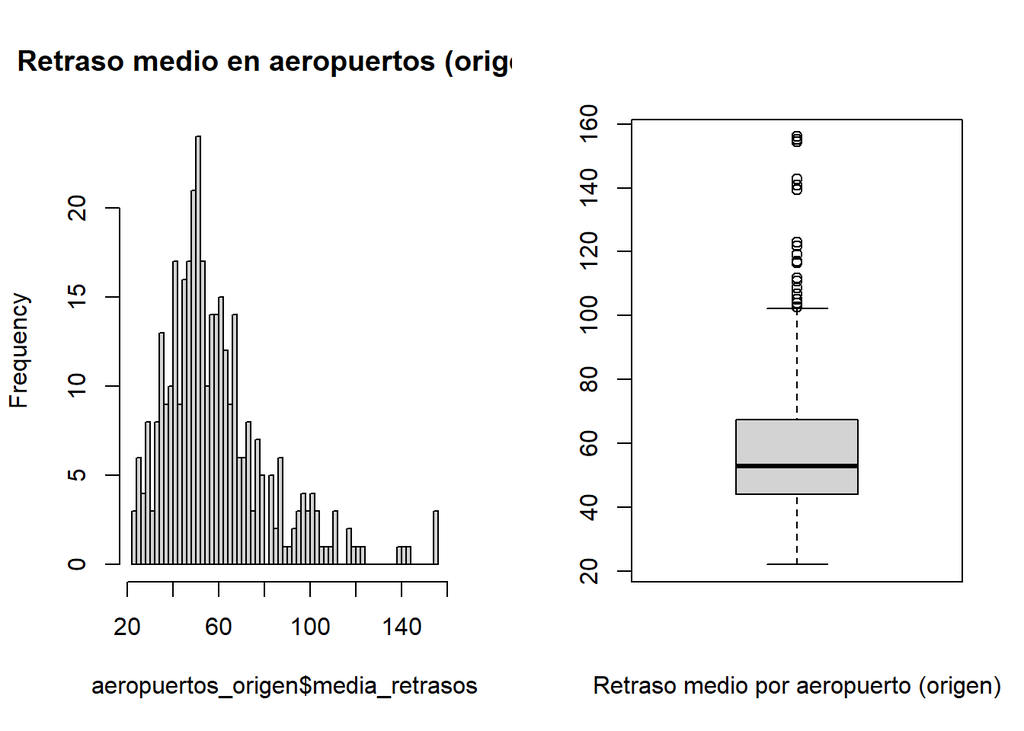

```r
par(mfrow = c(1,2))
hist(aeropuertos_origen$media_retrasos, 50,  main = "Retraso medio en aeropuertos (origen)")
boxplot(aeropuertos_origen$media_retrasos, xlab = "Retraso medio por aeropuerto (origen)")
```

A partir del histograma y del gráfico de caja y bigotes, podemos observar como la media de retraso sigue una distribución normal a pesar de que posee cierta asimetría por la derecha así como algunos datos anómalos que trataremos de identificar a continuación. Una vez identificados creamos un subset con estos aeropuertos:

```r
max_vals = which(aeropuertos_origen$media_retrasos > quantile(aeropuertos_origen$media_retrasos, 0.95))

aer_anom_origen = aeropuertos_origen[max_vals, ]

summary(aer_anom_origen)
```

```
##     ORIGIN           total_vuelos    vuelos_retrasados vuelos_adelantados
##  Length:18          Min.   : 354.0   Min.   : 26.00    Min.   :276.0
##  Class :character   1st Qu.: 513.2   1st Qu.: 95.75    1st Qu.:455.0
##  Mode  :character   Median : 620.5   Median :122.50    Median :485.5
##                     Mean   : 630.3   Mean   :121.78    Mean   :497.1
##                     3rd Qu.: 701.5   3rd Qu.:138.75    3rd Qu.:531.0
##                     Max.   :1045.0   Max.   :228.00    Max.   :801.0
##  vuelos_puntuales  prob_retraso    media_retrasos  adelanto_medio
##  Min.   : 1.00    Min.   :0.0500   Min.   :104.0   Min.   : 5.890
##  1st Qu.: 7.25    1st Qu.:0.1650   1st Qu.:111.1   1st Qu.: 7.438
##  Median :10.50    Median :0.2100   Median :118.1   Median : 8.250
##  Mean   :11.44    Mean   :0.1872   Mean   :124.7   Mean   : 8.231
##  3rd Qu.:13.50    3rd Qu.:0.2200   3rd Qu.:140.4   3rd Qu.: 9.213
##  Max.   :37.00    Max.   :0.2500   Max.   :156.0   Max.   :10.280
##     estado
##  Length:18
##  Class :character
##  Mode  :character
##
##
##
```

Poseemos 18 aeropuertos que superan el percentil 95, es decir, son aeropuertos que tienen vuelos con medias de retraso bastante grandes cuando actúan como aeropuerto de origen.En el resumen podemos observar medias de retraso enntre los 100 y 150 minutos. Podemos decir también de estos aeropuertos anómalos que no parecen ser muy grandes ya que, el aeropuerto con más vuelos en los que actuó como origen tiene únicamente 1045 vuelos en 2023, valor que no es grand en comparación al volumen de vuelos que poseen otros aeropuertos. En el estudio de estos anómalos, podemos preguntarnos si estos aeropuertos se encuentran en la misma zona dentro de EEUU. Para determinar esta cuestión, añadimos una nueva columna al dataframe que asigne a cada aeropuerto la región a la que pertenece (Noreste, Medioatlántica, Medio-oeste, Sur, Oeste y Territorios):

```r
regiones <- list(
    Noreste = c("Maine", "Vermont", "Massachusetts", "Rhode Island", "Connecticut", "New York", "New Jersey", "Pennsylvania", "New Hampshire"),
    Medioatlántica = c("Delaware", "Florida", "Georgia", "Maryland", "North Carolina", "South Carolina", "Virginia", "Washington D.C.", "West Virginia"),
    Mediooeste = c("Illinois", "Indiana", "Michigan", "Ohio", "Wisconsin", "Iowa", "Kansas", "Minnesota", "Missouri", "Nebraska", "North Dakota", "South Dakota"),
    Sur = c("Alabama", "Arkansas", "Kentucky", "Louisiana", "Mississippi", "Oklahoma", "Tennessee", "Texas"),
    Oeste = c("Alaska", "Arizona", "California", "Colorado", "Hawaii", "Idaho", "Montana", "Nevada", "New Mexico", "Oregon", "Utah", "Washington", "Wyoming"),
    Territorios = c("Puerto Rico", "U.S. Virgin Islands", "Guam", "American Samoa", "Northern Mariana Islands")
)

asignar_region <- function(estado) {
  for (region in names(regiones)) {
    if (estado %in% regiones[[region]]) {
      return(region)
    }
  }
}

aer_anom_origen<- aer_anom_origen %>%
  mutate(region = sapply(estado, asignar_region))
```

Visualizamos en un gráfico de barras como se distribuyen estos aeropuertos según la región:

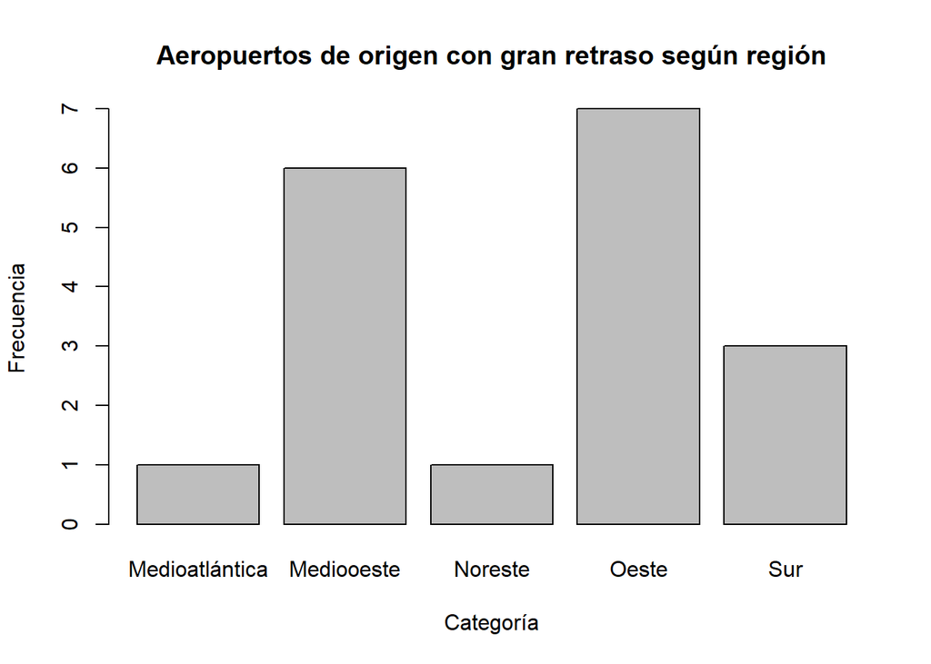

```r
frec <- table(aer_anom_origen$region)

barplot(frec, main = "Aeropuertos de origen con gran retraso según región",
        xlab = "Categoría", ylab = "Frecuencia")
```

Mediante el gráfico anterior, observamos como las regiones oeste y medio oeste son las más frecuentes dentro de estos aeropuertos con gran retraso. A continuación, trataremos de determinar cuál o cuáles son las causas principales de retraso para estos aeropuertos y si varían por las regiones más frecuentes:

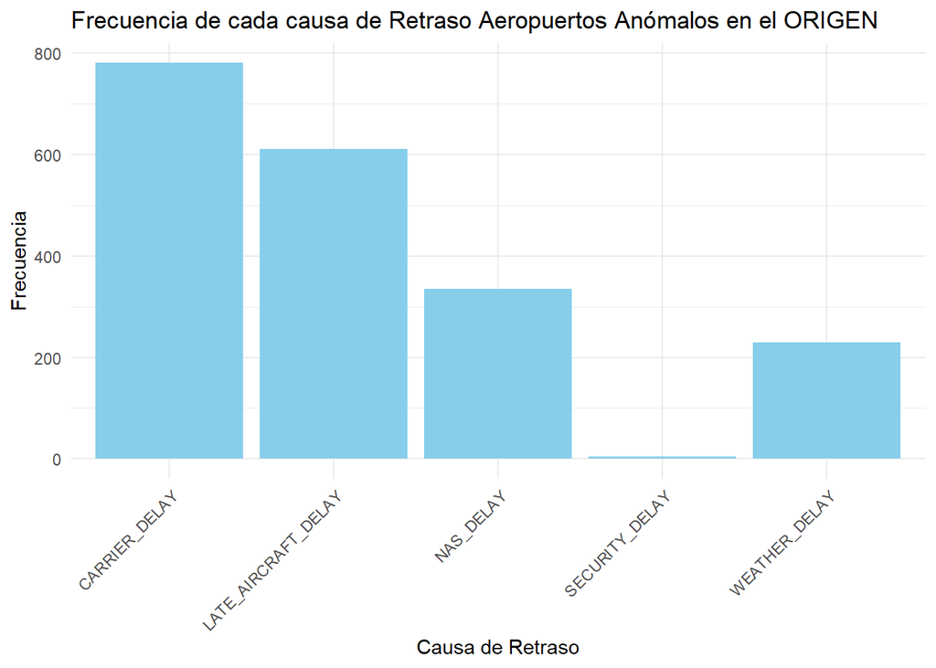

```r
aeropuertos_anomalos <- aer_anom_origen$ORIGIN
df_comp_aer_org <- df %>% filter(ORIGIN %in% aeropuertos_anomalos)

causas_retraso_subset <- df_comp_aer_org %>%
  dplyr::summarise(
    CARRIER_DELAY = sum(!is.na(CARRIER_DELAY) & CARRIER_DELAY > 0),
    WEATHER_DELAY = sum(!is.na(WEATHER_DELAY) & WEATHER_DELAY > 0),
    NAS_DELAY = sum(!is.na(NAS_DELAY) & NAS_DELAY > 0),
    SECURITY_DELAY = sum(!is.na(SECURITY_DELAY) & SECURITY_DELAY > 0),
    LATE_AIRCRAFT_DELAY = sum(!is.na(LATE_AIRCRAFT_DELAY) & LATE_AIRCRAFT_DELAY > 0)
  )


causas_retraso_subset_long <- causas_retraso_subset %>%
  pivot_longer(everything(), names_to = "causa", values_to = "frecuencia")


ggplot(causas_retraso_subset_long, aes(x = causa, y = frecuencia)) +
  geom_bar(stat = "identity", fill = "skyblue") +
  labs(title = "Frecuencia de cada causa de Retraso Aeropuertos Anómalos en el ORIGEN",
       x = "Causa de Retraso", y = "Frecuencia") +
  theme_minimal() +
  theme(axis.text.x = element_text(angle = 45, hjust = 1))
```

Podemos ver cómo CARRIER_DELAY (retraso de la operadora) es la causa más frecuente seguida de LATE_AIRCRAFT_DELAY (retraso de aeronave tardía). Comprobamos a continuación, si según la región de los anómalos varían las causas, nos centraremos en las regiones Oeste y Medio-Oeste que eran las más frecuentes:

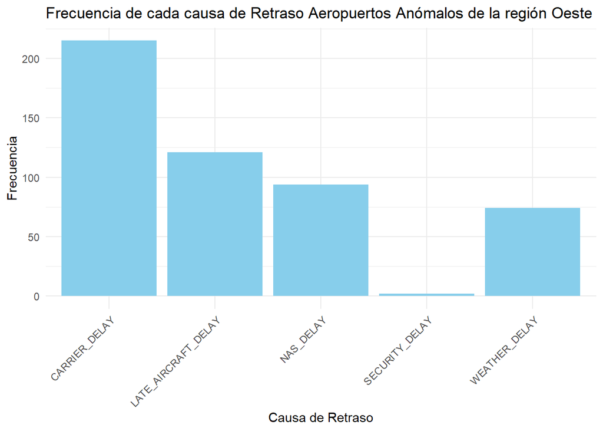

```r
aer_org2 = aer_anom_origen %>% filter(region == "Oeste")
aeropuertos_anomalos <- aer_org2$ORIGIN
df_comp_aer_org <- df %>% filter(ORIGIN %in% aeropuertos_anomalos)

causas_retraso_subset <- df_comp_aer_org %>%
  dplyr::summarise(
    CARRIER_DELAY = sum(!is.na(CARRIER_DELAY) & CARRIER_DELAY > 0),
    WEATHER_DELAY = sum(!is.na(WEATHER_DELAY) & WEATHER_DELAY > 0),
    NAS_DELAY = sum(!is.na(NAS_DELAY) & NAS_DELAY > 0),
    SECURITY_DELAY = sum(!is.na(SECURITY_DELAY) & SECURITY_DELAY > 0),
    LATE_AIRCRAFT_DELAY = sum(!is.na(LATE_AIRCRAFT_DELAY) & LATE_AIRCRAFT_DELAY > 0)
  )


causas_retraso_subset_long <- causas_retraso_subset %>%
  pivot_longer(everything(), names_to = "causa", values_to = "frecuencia")


ggplot(causas_retraso_subset_long, aes(x = causa, y = frecuencia)) +
  geom_bar(stat = "identity", fill = "skyblue") +
  labs(title = "Frecuencia de cada causa de Retraso Aeropuertos Anómalos de la región Oeste",
       x = "Causa de Retraso", y = "Frecuencia") +
  theme_minimal() +
  theme(axis.text.x = element_text(angle = 45, hjust = 1))
```

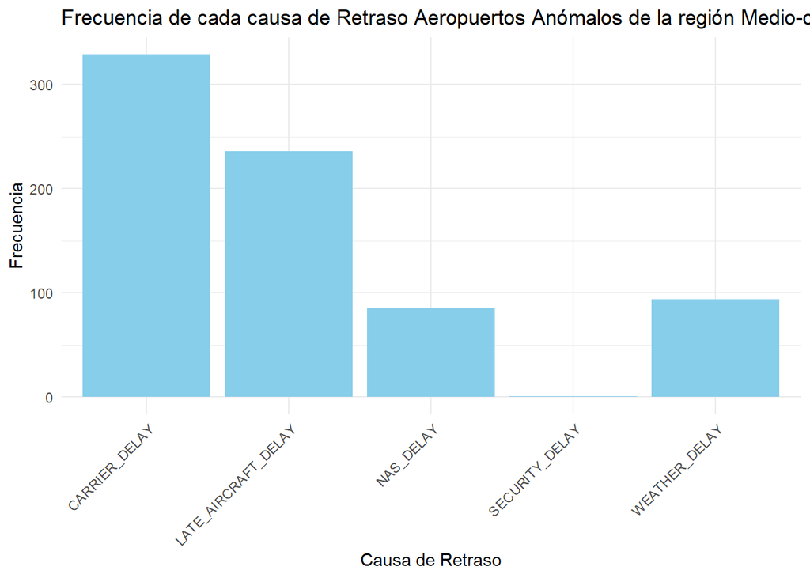

```r
aer_org3= aer_anom_origen %>% filter(region == "Mediooeste")
aeropuertos_anomalos <- aer_org3$ORIGIN
df_comp_aer_org <- df %>% filter(ORIGIN %in% aeropuertos_anomalos)

causas_retraso_subset <- df_comp_aer_org %>%
  dplyr::summarise(
    CARRIER_DELAY = sum(!is.na(CARRIER_DELAY) & CARRIER_DELAY > 0),
    WEATHER_DELAY = sum(!is.na(WEATHER_DELAY) & WEATHER_DELAY > 0),
    NAS_DELAY = sum(!is.na(NAS_DELAY) & NAS_DELAY > 0),
    SECURITY_DELAY = sum(!is.na(SECURITY_DELAY) & SECURITY_DELAY > 0),
    LATE_AIRCRAFT_DELAY = sum(!is.na(LATE_AIRCRAFT_DELAY) & LATE_AIRCRAFT_DELAY > 0)
  )


causas_retraso_subset_long <- causas_retraso_subset %>%
  pivot_longer(everything(), names_to = "causa", values_to = "frecuencia")


ggplot(causas_retraso_subset_long, aes(x = causa, y = frecuencia)) +
  geom_bar(stat = "identity", fill = "skyblue") +
  labs(title = "Frecuencia de cada causa de Retraso Aeropuertos Anómalos de la región Medio-oeste",
       x = "Causa de Retraso", y = "Frecuencia") +
  theme_minimal() +
  theme(axis.text.x = element_text(angle = 45, hjust = 1))
```

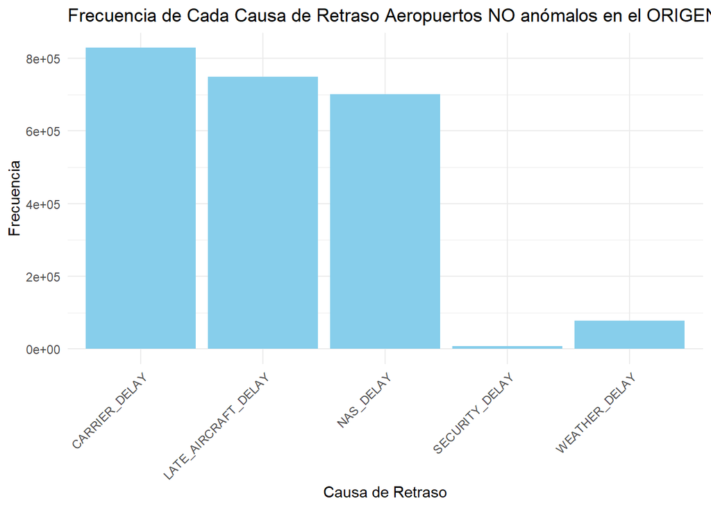

```r
aeropuertos_anomalos <- aer_org3$ORIGIN
df_aer_org_ok <- df %>% filter(!(ORIGIN %in% aeropuertos_anomalos))

causas_retraso_subset <- df_aer_org_ok %>%
  dplyr::summarise(
    CARRIER_DELAY = sum(!is.na(CARRIER_DELAY) & CARRIER_DELAY > 0),
    WEATHER_DELAY = sum(!is.na(WEATHER_DELAY) & WEATHER_DELAY > 0),
    NAS_DELAY = sum(!is.na(NAS_DELAY) & NAS_DELAY > 0),
    SECURITY_DELAY = sum(!is.na(SECURITY_DELAY) & SECURITY_DELAY > 0),
    LATE_AIRCRAFT_DELAY = sum(!is.na(LATE_AIRCRAFT_DELAY) & LATE_AIRCRAFT_DELAY > 0)
  )

causas_retraso_subset_long <- causas_retraso_subset %>%
  pivot_longer(everything(), names_to = "causa", values_to = "frecuencia")

ggplot(causas_retraso_subset_long, aes(x = causa, y = frecuencia)) +
  geom_bar(stat = "identity", fill = "skyblue") +
  labs(title = "Frecuencia de Cada Causa de Retraso Aeropuertos NO anómalos en el ORIGEN ",
       x = "Causa de Retraso", y = "Frecuencia") +
  theme_minimal() +
  theme(axis.text.x = element_text(angle = 45, hjust = 1))
```

Podemos ver que la tendencia es similar a los casos anteriores a pesar de que LATE_AIRCRAFT_DELAY(retraso de aeronave tardía) y NAS_DELAY (retraso del Sistema Aéreo Nacional de EEUU) tengan una frecuencia más parecida.

Por otro lado, podemos plantaearnos si los aeropuertos con mayor número de vuelos poseen por defecto mayor o menor probabilidad de retraso. Para ello, planteamos un test de hipótesis para determinar la correlación entre estas variables:

```r
cor_test_result <- cor.test(aeropuertos_origen$total_vuelos, aeropuertos_origen$prob_retraso, use = "complete.obs")
print(cor_test_result)
```

```
##
##  Pearson's product-moment correlation
##
## data:  aeropuertos_origen$total_vuelos and aeropuertos_origen$prob_retraso
## t = 7.381, df = 357, p-value = 1.114e-12
## alternative hypothesis: true correlation is not equal to 0
## 95 percent confidence interval:
##  0.2705498 0.4504085
## sample estimates:
##       cor
## 0.3638661
```

Observando el resultado, vemos que el p-valor es menor que 0.05, es decir, rechazamos la hipótesis nula de que la correlación fuese 0 entre las 2 variables. Luego, sabemos que la correlación entre estas variables estará contenida entre 0.27 y 0.45 con un 95% de confianza. A partir del valor de 0.36 de la correlación de Pearson, podemos decir que el número total de vuelos en el origen de cada aeropuerto guarda un relación positiva moderada con la probabilidad de retraso, es decir, conforme aumentan los vuelos tiende a aumentar también la probabilidad de retraso, pero esta relación no es demasiado fuerte. Representamos en un diagrama de dispersión los aeropuertos:

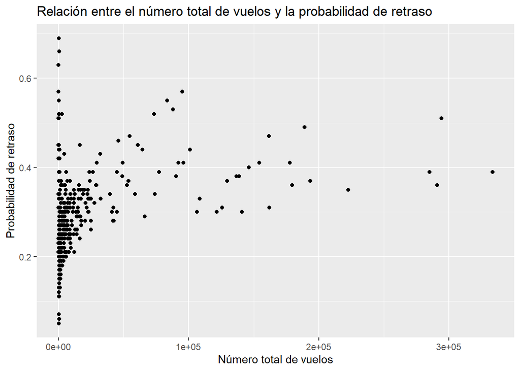

```r
ggplot(aeropuertos_origen, aes(x = total_vuelos, y = prob_retraso)) +
  geom_point() +
  labs(title = "Relación entre el número total de vuelos y la probabilidad de retraso",
       x = "Número total de vuelos",
       y = "Probabilidad de retraso")
```

Podemos observar que a medida que aumentan los vuelos para cada aeropuerto cuando actúa como origen, suele aumentar la probabilidad de retraso pero no es una relación fuerte y no se cumple en algunos casos. A partir del gráfico podemos darnos cuenta de la gran variación existente entre los aeropuertos con muy pocos vuelos. Observamos desde aeropuertos con pocos vuelos y poca probabilidad de retraso, pero encontramos también otros aeropuertos con pocos vuelos pero mucha probabilidad de retraso.

Ahora, estudiaremos la relación entre la probabilidad de retraso y la media de los vuelos retrasados en minutos para cada aeropuerto cuando actúa como origen. Procedemos de igual manera que antes:

```r
cor_test_result <- cor.test(aeropuertos_origen$media_retrasos, aeropuertos_origen$prob_retraso, use = "complete.obs")
print(cor_test_result)
```

```
##
##  Pearson's product-moment correlation
##
## data:  aeropuertos_origen$media_retrasos and aeropuertos_origen$prob_retraso
## t = -10.028, df = 357, p-value < 2.2e-16
## alternative hypothesis: true correlation is not equal to 0
## 95 percent confidence interval:
##  -0.5458248 -0.3839285
## sample estimates:
##        cor
## -0.4688046
```

Podemos ver, que se vuelve a rechazar la hipótesis nula (correlación 0 entre las dos variables) ya que, el p-valor es menor que 0.05. Por otro lado, con un nivel de confianza del 95% sabemos que la correlación estará entre un -0.54 y un -0.38. El valor estimado que obtenemos de la correlación de Pearson es de -0.468 lo que indica que la media de retrasos y la probabilidad de retraso están inversamente correlacioadas, es decir, a pesar de que haya aeropuertos que proporcionan un mayor número de vuelos retrasados, estos se retrasan menos que otros aeropuertos que poseen una menor probabilidad de retraso. Podemos pensar que los aeropuertos con mayor probabilidad de retraso pueden llevar a cabo estrategias que les ayuden a disminuir este tiempo.

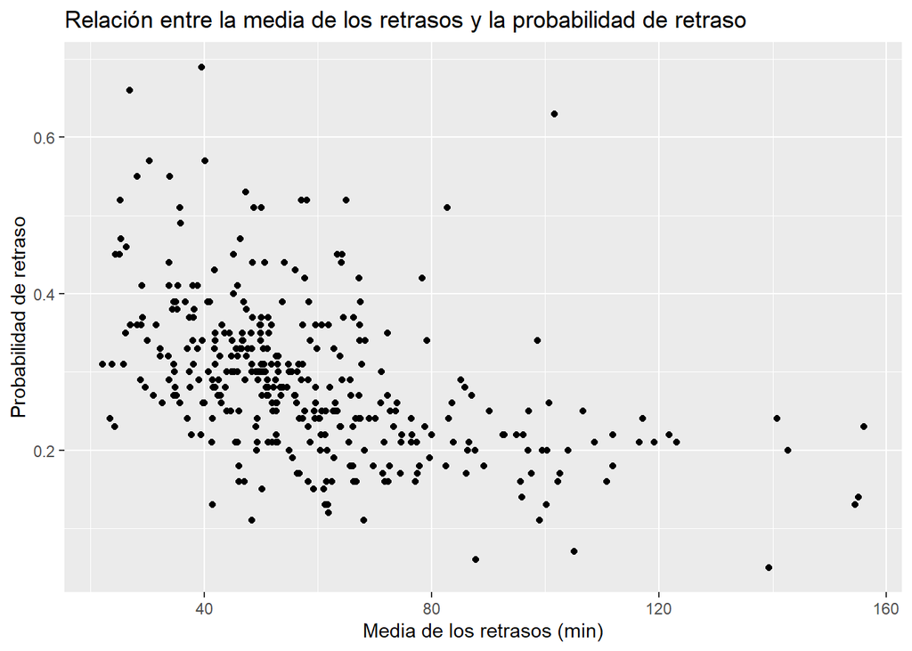

```r
ggplot(aeropuertos_origen, aes(x = media_retrasos, y = prob_retraso)) +
  geom_point() +
  labs(title = "Relación entre la media de los retrasos y la probabilidad de retraso",
       x = "Media de los retrasos (min)",
       y = "Probabilidad de retraso")
```

En el gráfico de dispersión se confirma lo mencionado anteriormente.

Por último, antes de continuar con el estudio de la actuación de los aeropuertos cuando actuaron como destino, calculamos un índice de actuación para cada aeropuerto para poder clasificarlos y compararlo con su actuacíon cuando son el aeropuerto de destino:

```r
aeropuertos_origen$indice_actuacion <- aeropuertos_origen$prob_retraso * aeropuertos_origen$media_retrasos
```

Categorizamos los índices calculados, un aeropuerto habrá tenido una mejor actuación como origen cuanto más pequeño sea su valor en este índice calculado:

```r
aeropuertos_origen$indice_categoria <- cut(aeropuertos_origen$indice_actuacion,
                                           breaks = quantile(aeropuertos_origen$indice_actuacion, probs = seq(0, 1, 0.25), na.rm = TRUE),
                                           include.lowest = TRUE,
                                           labels = c("Muy Bueno", "Bueno", "Regular", "Malo"))

table(aeropuertos_origen$indice_categoria)
```

```
##
## Muy Bueno     Bueno   Regular      Malo
##        90        90        89        90
```

## 2.2 Estudio aeropuertos cuando actúan destino.

Continuamos con el estudio pero a continuación, nos centramos en el resumen de la información respectiva a los vuelos de cada aeropuerto cuando estos actuaron como destino. Mostramos el resumen de las variables de tipo numérico:

```r
summary(aeropuertos_destino[,descResAer_dest$variable[descResAer_dest$tipo == "numerical"]])
```

```
##   total_vuelos      vuelos_retrasados  vuelos_adelantados vuelos_puntuales
##  Min.   :    25.0   Min.   :     3.0   Min.   :    22.0   Min.   :   0.0
##  1st Qu.:   718.5   1st Qu.:   227.5   1st Qu.:   528.5   1st Qu.:  14.0
##  Median :  2905.0   Median :  1046.0   Median :  1868.0   Median :  60.0
##  Mean   : 19963.9   Mean   :  7271.8   Mean   : 12322.9   Mean   : 369.2
##  3rd Qu.: 13181.5   3rd Qu.:  5027.5   3rd Qu.:  8281.5   3rd Qu.: 287.0
##  Max.   :333384.0   Max.   :109987.0   Max.   :227289.0   Max.   :5602.0
##   prob_retraso    retraso_medio    adelanto_medio
##  Min.   :0.1000   Min.   : 16.28   Min.   : 6.27
##  1st Qu.:0.2800   1st Qu.: 34.50   1st Qu.:12.12
##  Median :0.3400   Median : 40.96   Median :13.27
##  Mean   :0.3312   Mean   : 42.48   Mean   :13.43
##  3rd Qu.:0.3800   3rd Qu.: 47.34   3rd Qu.:14.36
##  Max.   :0.6200   Max.   :146.66   Max.   :24.58
```

```r
mySD = apply(aeropuertos_destino[,descResAer_dest$variable[descResAer_dest$tipo == "numerical"]], 2, sd)
# Mejor calcular el coeficiente de variación porque no depende de las unidades o magnitud de las variables
myMU = colMeans(aeropuertos_destino[,descResAer_dest$variable[descResAer_dest$tipo == "numerical"]])
myCV = mySD/myMU
sort(myCV)
```

```
##     adelanto_medio       prob_retraso      retraso_medio   vuelos_puntuales
##          0.1464766          0.2385339          0.3192748          2.2344725
##  vuelos_retrasados       total_vuelos vuelos_adelantados
##          2.3010422          2.3339295          2.3722706
```

A partir del resumen estadístico y de los coeficientes de variación observamos CV’s y distribuciones parecidas en todas las variables como es lógico. Como era de esperar, las variables que hacen referencia al número de vuelos son las que más varían al igual que antes. Podemos destacar que, en los aeropuertos de destino, el CV de la probabilidad de retraso es algo más pequeño que anteriormente. Por otra parte, como seguimos teniendo valores bastante altos en el retraso medio, realizamos un histograma y un box&whisker al igual que antes, pero esta vez con los datos de cada aeropuerto cuando actúan como destino:

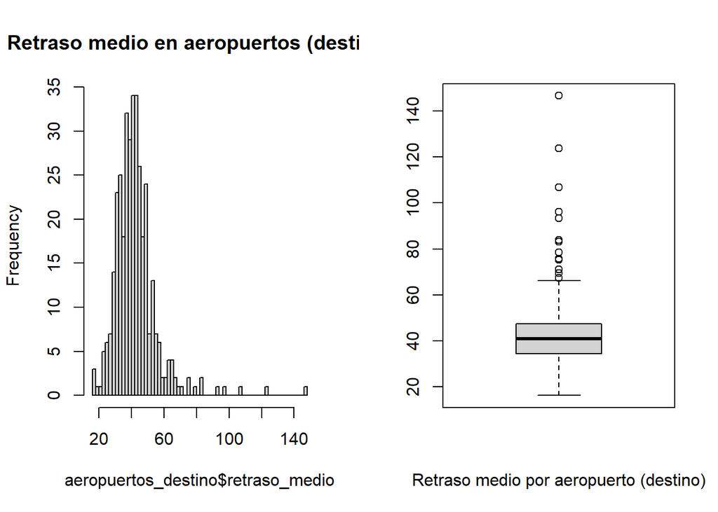

```r
par(mfrow = c(1,2))
hist(aeropuertos_destino$retraso_medio, 50,  main = "Retraso medio en aeropuertos (destino)")
boxplot(aeropuertos_destino$retraso_medio, xlab = "Retraso medio por aeropuerto (destino)")
```

A partir del histograma y del box&whisker podemos ver como el retraso medio para los aeropuertos cuando actúan como destino sigue una distribución normal, algo asimétrica por la derecha pero en menor medida que antes. En el gráfico de caja y bigotes visualizamos aeropuertos anómalos, con exceso de retraso.Ahora, los identificamos y los comparamos con los anómalos anteriores:

```r
max_vals2 = which(aeropuertos_destino$retraso_medio > quantile(aeropuertos_destino$retraso_medio, 0.95))

aer_anom_dest = aeropuertos_destino[max_vals2, ]

summary(aer_anom_dest)
```

```
##      DEST            total_vuelos    vuelos_retrasados vuelos_adelantados
##  Length:18          Min.   :  43.0   Min.   :  13.0    Min.   : 29.0
##  Class :character   1st Qu.: 618.0   1st Qu.: 138.2    1st Qu.:462.5
##  Mode  :character   Median : 688.0   Median : 165.0    Median :475.0
##                     Mean   : 725.8   Mean   : 229.4    Mean   :484.3
##                     3rd Qu.: 711.8   3rd Qu.: 222.5    3rd Qu.:510.5
##                     Max.   :1976.0   Max.   :1220.0    Max.   :962.0
##  vuelos_puntuales  prob_retraso    retraso_medio    adelanto_medio
##  Min.   : 1.00    Min.   :0.1700   Min.   : 64.11   Min.   :11.54
##  1st Qu.: 8.25    1st Qu.:0.2225   1st Qu.: 66.46   1st Qu.:13.70
##  Median : 9.50    Median :0.2400   Median : 75.47   Median :15.47
##  Mean   :12.11    Mean   :0.2806   Mean   : 83.13   Mean   :16.05
##  3rd Qu.:15.50    3rd Qu.:0.3000   3rd Qu.: 90.99   3rd Qu.:17.77
##  Max.   :35.00    Max.   :0.6200   Max.   :146.66   Max.   :24.58
##     estado
##  Length:18
##  Class :character
##  Mode  :character
##
##
##
```

Observamos de nuevo como los aeropuertos de destino que son anómalos, no manejan una cantidad excesiva de vuelos al igual que sucedía anteriormente. Antes de estudiar las regiones a las que pertenecen y sus causas de retraso más frecuentes, comprobamos si hay aeropuertos que son anómalos tanto en el origen como en el destino:

```r
noms_aeropuertos_origen <- aer_anom_origen$ORIGIN
noms_aeropuertos_destino <- aer_anom_dest$DEST
aeropuertos_anomalos_comunes <- intersect(noms_aeropuertos_origen, noms_aeropuertos_destino)
print(aeropuertos_anomalos_comunes)
```

```
## [1] "CIU" "CYS" "DDC" "DVL" "MEI" "PIB"
```

```r
aer_anom_dest<- aer_anom_dest %>%
  mutate(region = sapply(estado, asignar_region))
```

Imprimimos sus respectivos datos cuando actúan como origen y destino:

```r
aeropuertos_anom_origen_comunes <- aer_anom_origen %>%
  filter(ORIGIN %in% aeropuertos_anomalos_comunes)


aeropuertos_anom_destino_comunes <- aer_anom_dest %>%
  filter(DEST %in% aeropuertos_anomalos_comunes)


print(aeropuertos_anom_origen_comunes)
```

```
## # A tibble: 6 × 10
##   ORIGIN total_vuelos vuelos_retrasados vuelos_adelantados vuelos_puntuales
##   <chr>         <int>             <int>              <int>            <int>
## 1 CIU             710               169                504               37
## 2 CYS             354                71                276                7
## 3 DDC             595               132                458                5
## 4 DVL             629               132                489                8
## 5 MEI             676               141                525               10
## 6 PIB             617               113                486               18
## # ℹ 5 more variables: prob_retraso <dbl>, media_retrasos <dbl>,
## #   adelanto_medio <dbl>, estado <chr>, region <chr>
```

```r
print(aeropuertos_anom_destino_comunes)
```

```
## # A tibble: 6 × 10
##   DEST  total_vuelos vuelos_retrasados vuelos_adelantados vuelos_puntuales
##   <chr>        <int>             <int>              <int>            <int>
## 1 CIU            704               209                479               16
## 2 CYS            356                68                284                4
## 3 DDC            607               138                460                9
## 4 DVL            630               139                479               12
## 5 MEI            674               156                509                9
## 6 PIB            616               140                467                9
## # ℹ 5 more variables: prob_retraso <dbl>, retraso_medio <dbl>,
## #   adelanto_medio <dbl>, estado <chr>, region <chr>
```

Podemos destacar de estos aeropuertos que en ambos casos ninguno supera los 1000 vuelos en todo el año. Por otro lado, cuando actúan como origen poseen probabilidades de retraso similares, entre 0.18 y 0.24, a pesar de poseer probabilidades de retraso no muy altas, en el origen proporcionan retrasos muy elevados.Si observamos su probabilidades de retraso cuando actúan como destino, podemos ver como tienen valores similares (de 0.2 a 0.3) entre sí y un poco más elevados que en el origen, pero al contrario que antes, cuando son el aeropuerto de destino, a pesar de tener más probabilidad de retraso en conjunto su media es menor a excepción del aeropuerto CYS que proporciona retrasos excesivamente grandes en ambos casos.

Estudiamos ahora las regiones a las que pertenecen estos aeropuertos y las causas de retraso más frecuentes para los aeropuertos cuando actúan como destino:

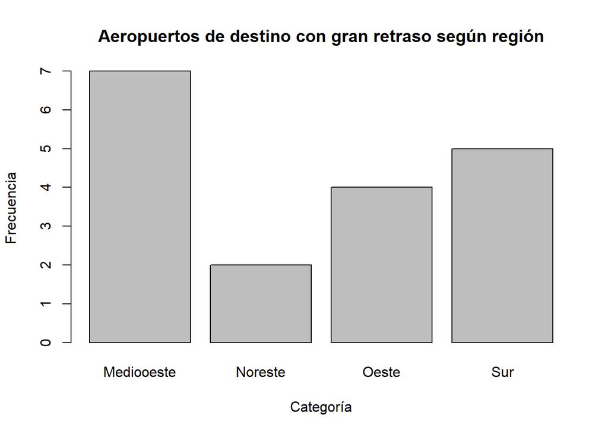

```r
frec <- table(aer_anom_dest$region)

barplot(frec, main = "Aeropuertos de destino con gran retraso según región",
        xlab = "Categoría", ylab = "Frecuencia")
```

Ahora, la región más común es la Medio-Oeste que para los aeropuertos de origen ocupaba la segunda plaza. Por otro lado, la región Oeste que antes ocupaba la primera plaza ahora ocupa la tercera por detrás de la región Sur. Estudiamos las causas más frecuentes:

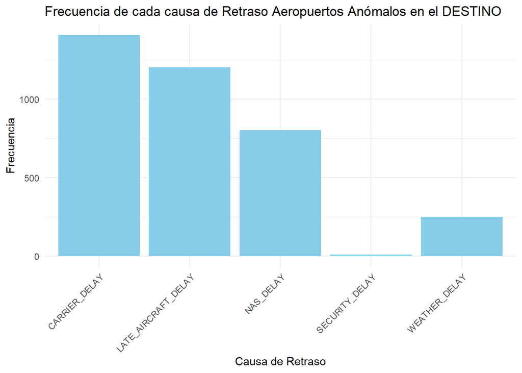

```r
aeropuertos_anomalos2 <- aer_anom_dest$DEST
df_comp_aer_dest <- df %>% filter(DEST %in% aeropuertos_anomalos2)

causas_retraso_subset2 <- df_comp_aer_dest %>%
  dplyr::summarise(
    CARRIER_DELAY = sum(!is.na(CARRIER_DELAY) & CARRIER_DELAY > 0),
    WEATHER_DELAY = sum(!is.na(WEATHER_DELAY) & WEATHER_DELAY > 0),
    NAS_DELAY = sum(!is.na(NAS_DELAY) & NAS_DELAY > 0),
    SECURITY_DELAY = sum(!is.na(SECURITY_DELAY) & SECURITY_DELAY > 0),
    LATE_AIRCRAFT_DELAY = sum(!is.na(LATE_AIRCRAFT_DELAY) & LATE_AIRCRAFT_DELAY > 0)
  )


causas_retraso_subset_long2 <- causas_retraso_subset2 %>%
  pivot_longer(everything(), names_to = "causa", values_to = "frecuencia")


ggplot(causas_retraso_subset_long2, aes(x = causa, y = frecuencia)) +
  geom_bar(stat = "identity", fill = "skyblue") +
  labs(title = "Frecuencia de cada causa de Retraso Aeropuertos Anómalos en el DESTINO",
       x = "Causa de Retraso", y = "Frecuencia") +
  theme_minimal() +
  theme(axis.text.x = element_text(angle = 45, hjust = 1))
```

Podemos observar que la tendencia de las causas de retraso es la misma que para los anómalos de origen. Podemos visualizar también las causas de retraso más frecuentes para los que son anómalos tanto en origen como en el destino:

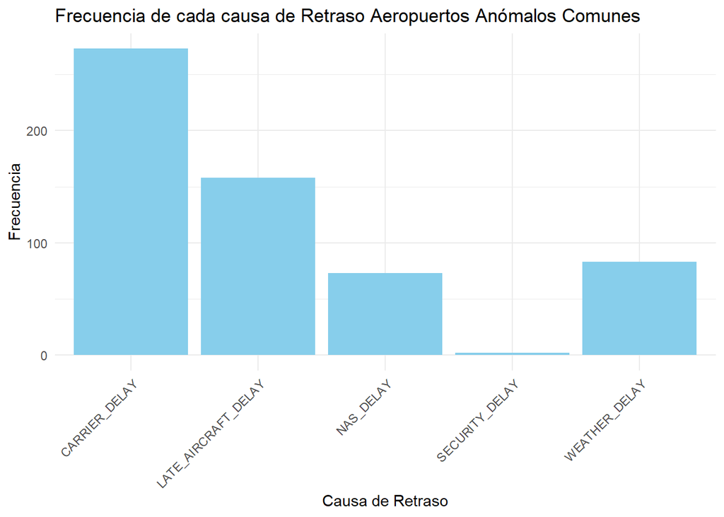

```r
aeropuertos_anomalos3 <- aeropuertos_anom_origen_comunes$ORIGIN
df_comp_aer_org2 <- df %>% filter(ORIGIN %in% aeropuertos_anomalos3)

causas_retraso_subset3 <- df_comp_aer_org2 %>%
  dplyr::summarise(
    CARRIER_DELAY = sum(!is.na(CARRIER_DELAY) & CARRIER_DELAY > 0),
    WEATHER_DELAY = sum(!is.na(WEATHER_DELAY) & WEATHER_DELAY > 0),
    NAS_DELAY = sum(!is.na(NAS_DELAY) & NAS_DELAY > 0),
    SECURITY_DELAY = sum(!is.na(SECURITY_DELAY) & SECURITY_DELAY > 0),
    LATE_AIRCRAFT_DELAY = sum(!is.na(LATE_AIRCRAFT_DELAY) & LATE_AIRCRAFT_DELAY > 0)
  )


causas_retraso_subset_long3<- causas_retraso_subset3 %>%
  pivot_longer(everything(), names_to = "causa", values_to = "frecuencia")


ggplot(causas_retraso_subset_long3, aes(x = causa, y = frecuencia)) +
  geom_bar(stat = "identity", fill = "skyblue") +
  labs(title = "Frecuencia de cada causa de Retraso Aeropuertos Anómalos Comunes",
       x = "Causa de Retraso", y = "Frecuencia") +
  theme_minimal() +
  theme(axis.text.x = element_text(angle = 45, hjust = 1))
```

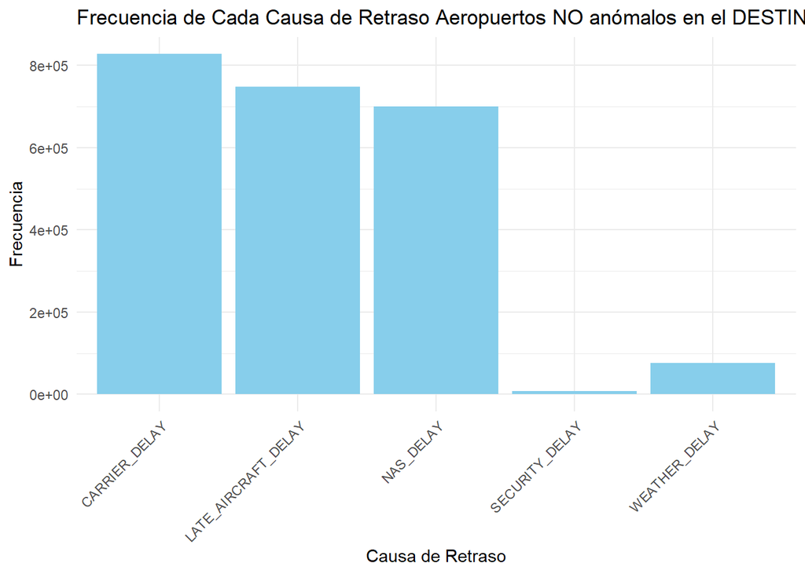

```r
aeropuertos_anomalos2 <- aer_anom_dest$DEST
df_aer_org_ok2 <- df %>% filter(!(DEST %in% aeropuertos_anomalos2))

causas_retraso_subset <- df_aer_org_ok2 %>%
  dplyr::summarise(
    CARRIER_DELAY = sum(!is.na(CARRIER_DELAY) & CARRIER_DELAY > 0),
    WEATHER_DELAY = sum(!is.na(WEATHER_DELAY) & WEATHER_DELAY > 0),
    NAS_DELAY = sum(!is.na(NAS_DELAY) & NAS_DELAY > 0),
    SECURITY_DELAY = sum(!is.na(SECURITY_DELAY) & SECURITY_DELAY > 0),
    LATE_AIRCRAFT_DELAY = sum(!is.na(LATE_AIRCRAFT_DELAY) & LATE_AIRCRAFT_DELAY > 0)
  )

causas_retraso_subset_long <- causas_retraso_subset %>%
  pivot_longer(everything(), names_to = "causa", values_to = "frecuencia")

ggplot(causas_retraso_subset_long, aes(x = causa, y = frecuencia)) +
  geom_bar(stat = "identity", fill = "skyblue") +
  labs(title = "Frecuencia de Cada Causa de Retraso Aeropuertos NO anómalos en el DESTINO ",
       x = "Causa de Retraso", y = "Frecuencia") +
  theme_minimal() +
  theme(axis.text.x = element_text(angle = 45, hjust = 1))
```

Podemos ver que los anómalos comunes siguen la misma tendencia general que el conjunto de anómalos de origen y destino.Sin embargo, los retrasos causados por la climatología (WEATHER_DELAY) han superado a los retrasos del Sistema Aéreo Nacional de EEUU (NAS_DELAY).

Ahora, al igual que hicimos con la información respectiva a cada aeropuerto cuando actuaron como origen, extraeremos diferentes correlaciones. En primer lugar, estudiaremos la relación entre el total de vuelos y la probabilidad de retraso cuando un aeropuerto actúa como destino:

```r
cor_test_result <- cor.test(aeropuertos_destino$total_vuelos, aeropuertos_destino$prob_retraso, use = "complete.obs")
print(cor_test_result)
```

```
##
##  Pearson's product-moment correlation
##
## data:  aeropuertos_destino$total_vuelos and aeropuertos_destino$prob_retraso
## t = 3.4072, df = 357, p-value = 0.0007312
## alternative hypothesis: true correlation is not equal to 0
## 95 percent confidence interval:
##  0.07534271 0.27590253
## sample estimates:
##       cor
## 0.1774646
```

Se rechaza la hipótesis nula puesto que el p-valor (0.0007) es menor que 0.05. Por otro lado, el coeficiente de correlación de Pearson es de 0.17, lo que indica una relación débil, es decir, a medida que aumenta el número de vuelos para cada aeropuerto cuando actúa como destino, la probabilidad de retraso tiende a aumentar ligeramente, como hemos dicho, no es una relación fuerte y no se cumplirá para todos los aeropuertos. En este caso, la relación es más débil que cuando un aeropuerto actuaba como origen, es decir, cuántos más vuelos tuviera un aerpuerto como origen, tendería a aumentar su probabilidad de retraso, ahora, hemos visto que en cuántos más vuelos participe un aeropuerto como destino, la probabilidad de retraso tenderá a aumentar pero más ligeramente.

Realizando un diagrama de dispersión:

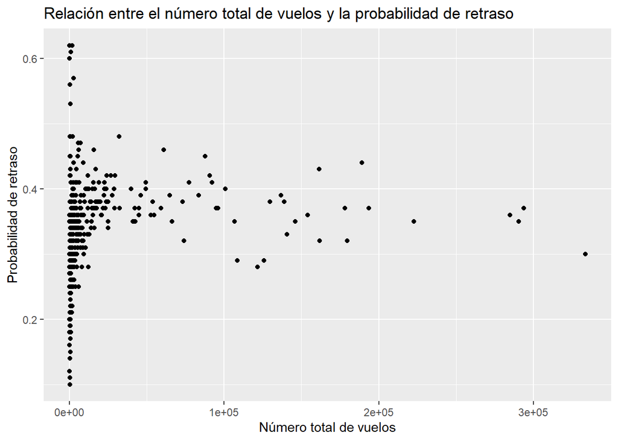

```r
ggplot(aeropuertos_destino, aes(x = total_vuelos, y = prob_retraso)) +
  geom_point() +
  labs(title = "Relación entre el número total de vuelos y la probabilidad de retraso",
       x = "Número total de vuelos",
       y = "Probabilidad de retraso")
```

Podemos confirmar lo mencionado anteriormente, la relación es muy débil entre el número de vuelos totales en los que un aerpoerto participa como destino y su probabilidad de retraso. Podemos volver a observar, al igual que en el gráfico que visualizaba esta relación pero cuando los aerpuertos actuaban como origen, que en los aeropuertos con pocos vuelos, hay mucha variación en la probabilidad de retraso.

Ahora, estudiaremos la relación entre la media de retraso que poporciona cada aeropuerto cuando actúan como destino con su probabilidad de retraso:

```r
cor_test_result <- cor.test(aeropuertos_destino$retraso_medio, aeropuertos_destino$prob_retraso, use = "complete.obs")
print(cor_test_result)
```

```
##
##  Pearson's product-moment correlation
##
## data:  aeropuertos_destino$retraso_medio and aeropuertos_destino$prob_retraso
## t = -2.0844, df = 357, p-value = 0.03783
## alternative hypothesis: true correlation is not equal to 0
## 95 percent confidence interval:
##  -0.210767170 -0.006218198
## sample estimates:
##        cor
## -0.1096535
```

Aunque observamos un coeficiente de correlación débil (-0.109), la relación entre estas variables es significativa ya que el p-valor es menor que 0.05. Este coeficiente nos hace pensar que los aeropuertos con mayor retraso medio cuando son el destino suelen tener una menor probabilidad de retraso. Sin embargo, la relación era más fuerte cuando los aeropuertos actuaban como origen, donde teníamos un coeficiente de Pearson de -0.46.

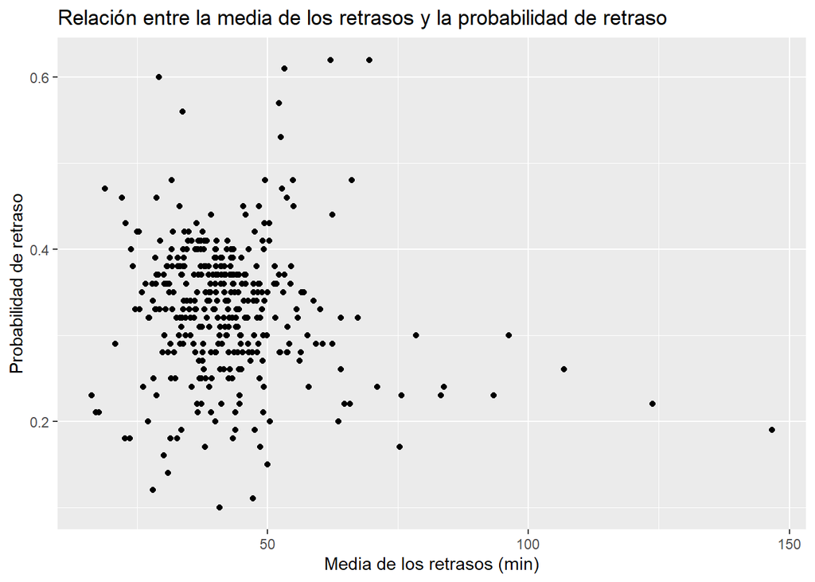

```r
ggplot(aeropuertos_destino, aes(x =retraso_medio, y = prob_retraso)) +
  geom_point() +
  labs(title = "Relación entre la media de los retrasos y la probabilidad de retraso",
       x = "Media de los retrasos (min)",
       y = "Probabilidad de retraso")
```

Al representar gráficamente, no observamos una relación o tendencia clara, al contrario que en el estudio de las actuaciones de cada aeropuerto en el origen donde podíamos observar con más claridad que los aeropuertos con mayor prob. de retraso en el origen tenían retrasos medios más pequeños que los aerpuertos con menor probabilidad de retraso.

Calculamos el índice de actuación para cada aeropuerto cuando actúa como destino:

```r
aeropuertos_destino <- aeropuertos_destino %>%
  mutate(indice_actuacion_d = retraso_medio * prob_retraso)
```

Los categorizamos:

```r
aeropuertos_destino$indice_categoria <- cut(aeropuertos_destino$indice_actuacion_d,
                                           breaks = quantile(aeropuertos_destino$indice_actuacion_d, probs = seq(0, 1, 0.25), na.rm = TRUE),
                                           include.lowest = TRUE,
                                           labels = c("Muy Bueno", "Bueno", "Regular", "Malo"))

table(aeropuertos_destino$indice_categoria)
```

```
##
## Muy Bueno     Bueno   Regular      Malo
##        90        90        89        90
```

## 2.3 Correlaciones entre origen y destino.

Ahora intentamos realizar una comparación entre estos índices para cada aeropuerto para determinar donde rinde mejor cada aeropuerto:

```r
origen_data <- aeropuertos_origen %>%
  select(ORIGIN, indice_actuacion)

destino_data <- aeropuertos_destino %>%
  select(DEST, indice_actuacion_d)

# Combinar los dataframes
comparacion_indices <- merge(origen_data, destino_data, by.x = "ORIGIN", by.y = "DEST", all = TRUE)

# Comparar los índices de rendimiento
comparacion_indices <- comparacion_indices %>%
  mutate(diferencia_indice = indice_actuacion - indice_actuacion_d)
```

A partir de la variable diferencia de índice podemos saber que, si un aeropuerto posee valor negativo en esta variable, actúa mejor en el origen que en el destino, por otro lado, si posee un valor positivo significa que ese aeropuerto actúa mejor cuando es el aeropuerto de destino. Si posee valores cercanos a 0 connota actuaciones similares en el origen y en el destino.

Visualizamos en un diagrama de dispersión la relación entre los índices de actuación:

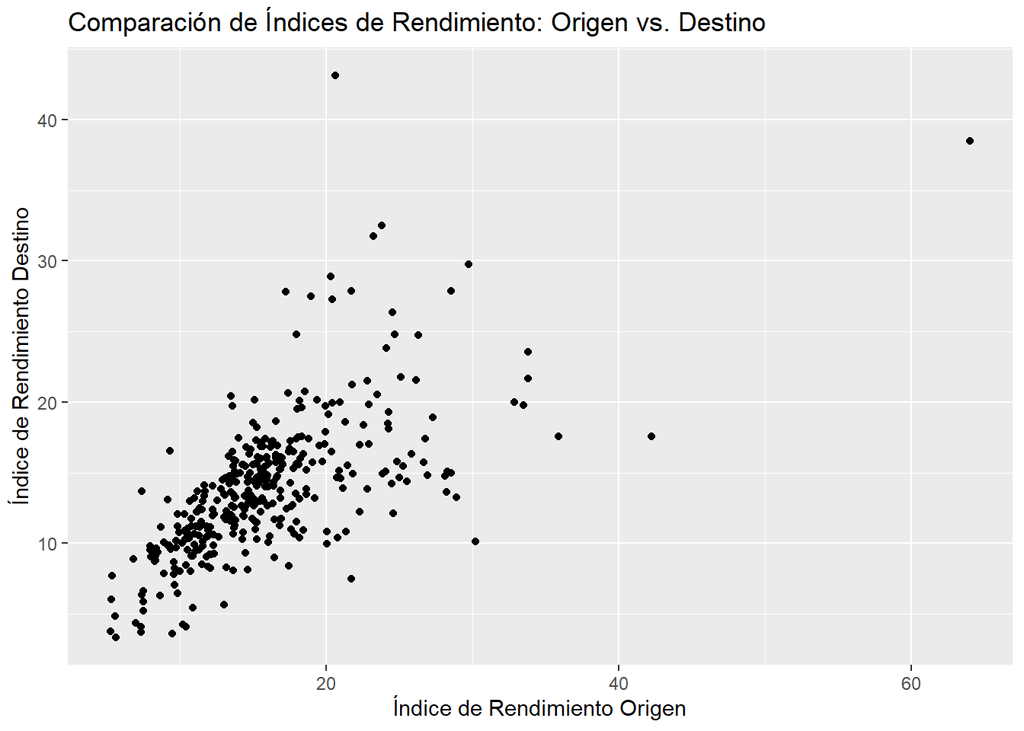

```r
ggplot(comparacion_indices, aes(x = indice_actuacion, y = indice_actuacion_d, label = ORIGIN)) +
  geom_point() +
  labs(title = "Comparación de Índices de Rendimiento: Origen vs. Destino",
       x = "Índice de Rendimiento Origen",
       y = "Índice de Rendimiento Destino")
```

```r
cor_test_result <- cor.test(comparacion_indices$indice_actuacion, comparacion_indices$indice_actuacion_d, use = "complete.obs")
print(cor_test_result)
```

```
##
##  Pearson's product-moment correlation
##
## data:  comparacion_indices$indice_actuacion and comparacion_indices$indice_actuacion_d
## t = 16.381, df = 357, p-value < 2.2e-16
## alternative hypothesis: true correlation is not equal to 0
## 95 percent confidence interval:
##  0.5916701 0.7103984
## sample estimates:
##       cor
## 0.6550593
```

Mediante el gráfico podemos observar que los aeropuertos, en su mayoría, suelen tener comportamientos similares tanto en el origen como en el destino, es decir, la mayoría de aeropuertos con índice alto en el origen (mal rendimiento) tendrá también un índice alto en el destino (mal rendimiento), y viceversa. Confirmamos esto a partir del coeficiente de correlación que es de 0.65 lo que indica una relación psitiva y fuerte, además, esta relación es significativa puesto que el p-valor es menor que 0.05.

Ahora resumiremos en una misma variable la información respectiva a cada aerpuerto:

```r
aeropuertos_combinados <- bind_rows(
  mutate(aeropuertos_origen, aeropuerto = ORIGIN, tipo = "origen"),
  mutate(aeropuertos_destino, aeropuerto = DEST, tipo = "destino")
)
```

```r
aeropuertos_RES <- aeropuertos_combinados %>%
  group_by(aeropuerto) %>%
  summarise(
    total_vuelos = sum(total_vuelos),
    total_vuelos_con_retraso = sum(vuelos_retrasados),
    total_vuelos_puntuales = sum(vuelos_puntuales),
    total_vuelos_adelantados=sum(vuelos_adelantados),
    prob_retraso_origen = mean(prob_retraso[tipo == "origen"]),
    prob_retraso_destino = mean(prob_retraso[tipo == "destino"]),
    retraso_medio_origen = mean(media_retrasos[tipo == "origen"]),
    retraso_medio_destino = mean(retraso_medio[tipo == "destino"]),
    estado = first(estado)
  )
```

En este dataset contenemos la siguiente información: **total_vuelos**: Número total de vuelos en los que participo el aeropuerto .  
**total_vuelos_con_retraso**: Número total de vuelos retrasados en los que participo el aeropuerto.  
**total_vuelos_puntuales**: Números total de vuelos puntuales en los que participo el aeropuerto.  
**total_vuelos_adelantados**: Número total de vuelos qque salieron antes de los previsto en los que participo el aeropuerto.  
**prob_retraso_origen**: Proporción de vuelos retrasados cuando ese aeropuerto actua como origen.  
**prob_retraso_destino**: Proporción de vuelos retrasados cuando ese aeropuerto actua como destino.  
**retraso_medio_origen**: Media en minutos de los vuelos que llegaron con retraso para ese aeropuerto cuando actuaba como origen.  
**retraso_medio_destino**: Media en minutos de los vuelos que llegaron con retraso para ese aeropuerto cuando actuaba como destino.  
**estado**: Estado al que pertenece el aeropuerto.

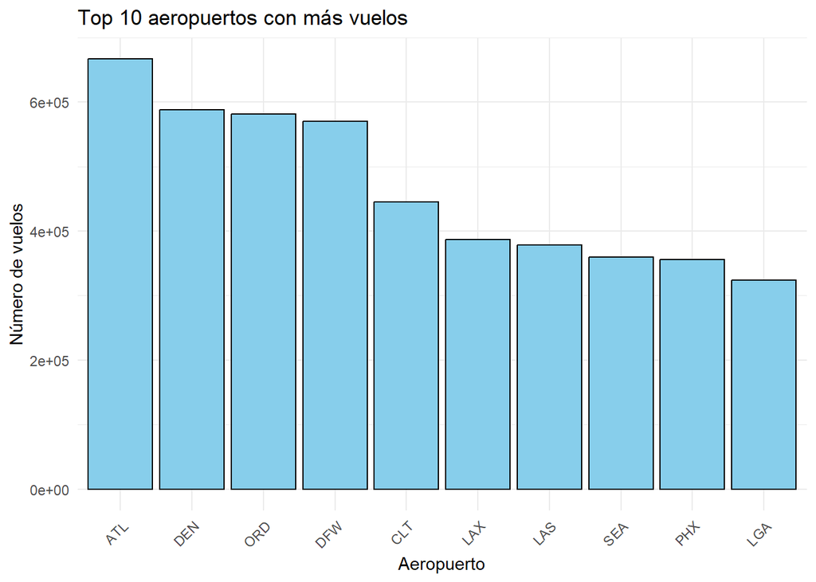

```r
top_10_aeropuertos <- aeropuertos_RES %>%
  arrange(desc(total_vuelos)) %>%
  slice_head(n = 10) %>%
  pull(aeropuerto)

datos_top_10 <- aeropuertos_RES %>%
  filter(aeropuerto %in% top_10_aeropuertos)

datos_top_10$aeropuerto <- factor(datos_top_10$aeropuerto, levels = top_10_aeropuertos)

ggplot(datos_top_10, aes(x = aeropuerto, y = total_vuelos)) +
  geom_bar(stat = "identity", fill = "skyblue", color = "black") +
  labs(x = "Aeropuerto", y = "Número de vuelos", title = "Top 10 aeropuertos con más vuelos") +
  theme_minimal() +
  theme(axis.text.x = element_text(angle = 45, hjust = 1))
```

## Preparación datos clustering

```r
cor_test_result <- cor.test(aeropuertos_RES$retraso_medio_origen, aeropuertos_RES$retraso_medio_destino, use = "complete.obs")
print(cor_test_result)
```

```
##
##  Pearson's product-moment correlation
##
## data:  aeropuertos_RES$retraso_medio_origen and aeropuertos_RES$retraso_medio_destino
## t = 12.57, df = 357, p-value < 2.2e-16
## alternative hypothesis: true correlation is not equal to 0
## 95 percent confidence interval:
##  0.4777841 0.6217573
## sample estimates:
##       cor
## 0.5538978
```

Observamos que la relación entre estas variables es significativa (p-valor<0.05). Además, se trata de una relación positiva moderada, es decir, los aeropuertos con una media alta de retraso en el origen tenderán a tener una media alta de retraso en el destino, y viceversa. Estudiamos ahora las relaciones entre las probabilidades de retraso en el origen y destino:

```r
cor_test_result <- cor.test(aeropuertos_RES$prob_retraso_origen, aeropuertos_RES$prob_retraso_destino, use = "complete.obs")
print(cor_test_result)
```

```
##
##  Pearson's product-moment correlation
##
## data:  aeropuertos_RES$prob_retraso_origen and aeropuertos_RES$prob_retraso_destino
## t = 16.228, df = 357, p-value < 2.2e-16
## alternative hypothesis: true correlation is not equal to 0
## 95 percent confidence interval:
##  0.5876813 0.7073561
## sample estimates:
##       cor
## 0.6515542
```

Vemos al igual que en el caso anterior que la relación entre estas variables es significativa (p-valor<0.05). Podemos decir que se trata de una relación positiva fuerte entre las probabilidades de retraso, es decir, los aeropuertos con altas probabilidades de retraso en el origen tenderán a tener unas probabilidades altas de retraso en el destino, y viceversa.

Como ambos pares de variables estan bastante correlacionadas, creamos dos nuevas variables que resumen el contenido de estos pares y las usaremos en el clustering que realizaremos posteriormente:

```r
aeropuertos_RES$media_retrasos=(aeropuertos_RES$retraso_medio_origen+aeropuertos_RES$retraso_medio_destino)/2
aeropuertos_RES$prob_retrasos=(aeropuertos_RES$prob_retraso_origen+aeropuertos_RES$prob_retraso_destino)/2
```

Excluimos los anómalos comunes (los anómalos tanto en origen como destino) ya que poseian valores extremadamente altos en las medias de retraso.

```r
aeropuertos_sin_anom <- aeropuertos_RES %>%
  filter(!(aeropuerto %in% aeropuertos_anomalos_comunes))
```

Ahora, excluimos las variables categóricas y seleccionamos las variables respectivas a los totales de vuelos y a las 2 nuevas variables creadas a partir de las medias de retraso(origen y destino) y probabilidades de retraso (origen y destino):

```r
datos_aerop <- aeropuertos_sin_anom %>%
  select(2,3,4,5,11,12)

datos_aer_df <- as.data.frame(datos_aerop)

# Asignar los nombres de fila
rownames(datos_aer_df) <- aeropuertos_sin_anom$aeropuerto
```

Comenzamos con el clustering. Primero, escalamos y centramos nuestros datos ya que, están en ud. distintas:

```r
d_aer = scale(datos_aer_df, center = TRUE, scale = TRUE)
```

## 2.4 Clustering

Se utilizará como medida de distancia la distancia euclídea, ya que en este caso nos interesa agrupar aeropuertos con valores similares en la información que albergamos, y no con perfiles similares en dichos parámetros.

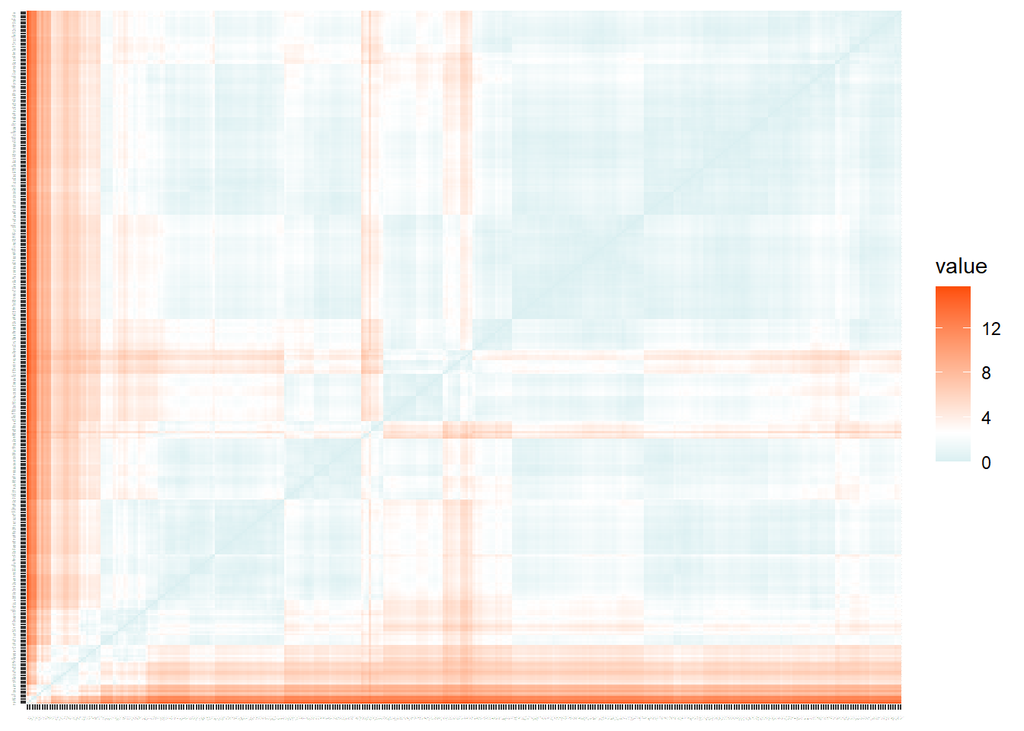

```r
midist <- get_dist(d_aer, stand = FALSE, method = "euclidean")
fviz_dist(midist, show_labels = TRUE, lab_size = 0.3,
          gradient = list(low = "#00AFBB", mid = "white", high = "#FC4E07"))
```

A través del mapa de color podemos observar un cluster de aeropuertos grandes pero también encontramos clusters más pequeños. Tampoco se observan un número determinado de clusters bien definidos pero proseguimos con el clustering.

```r
set.seed(100)
myN = c(52, 121, 207, 300)  # m
myhopkins = NULL
myseed = sample(1:1000, 10)
for (i in myN) {
  for (j in myseed) {
    tmp = get_clust_tendency(data = d_aer, n = i, graph = FALSE, seed = j)
    myhopkins = c(myhopkins, tmp$hopkins_stat)
  }
}
summary(myhopkins)
```

```
##    Min. 1st Qu.  Median    Mean 3rd Qu.    Max.
##  0.9348  0.9443  0.9460  0.9471  0.9501  0.9610
```

Empleando el estadístico de Hopkins nos confirma una cierta tendencia de agrupamiento, puesto que ha sido calculado para diferentes valores de m (n en la función) y con diferentes semillas aleatorias y sus valores oscilan entre 0.93 y 0.96, por tanto, es buen indicativo ya que son cercanos a 1.

### 2.4.1 Método de WARD

Primeramente, obtenemos el número óptimo de clusters con este algoritmo. Combinaremos el análisis del coeficiente de Silhouette con la variabilidad intra-cluster.

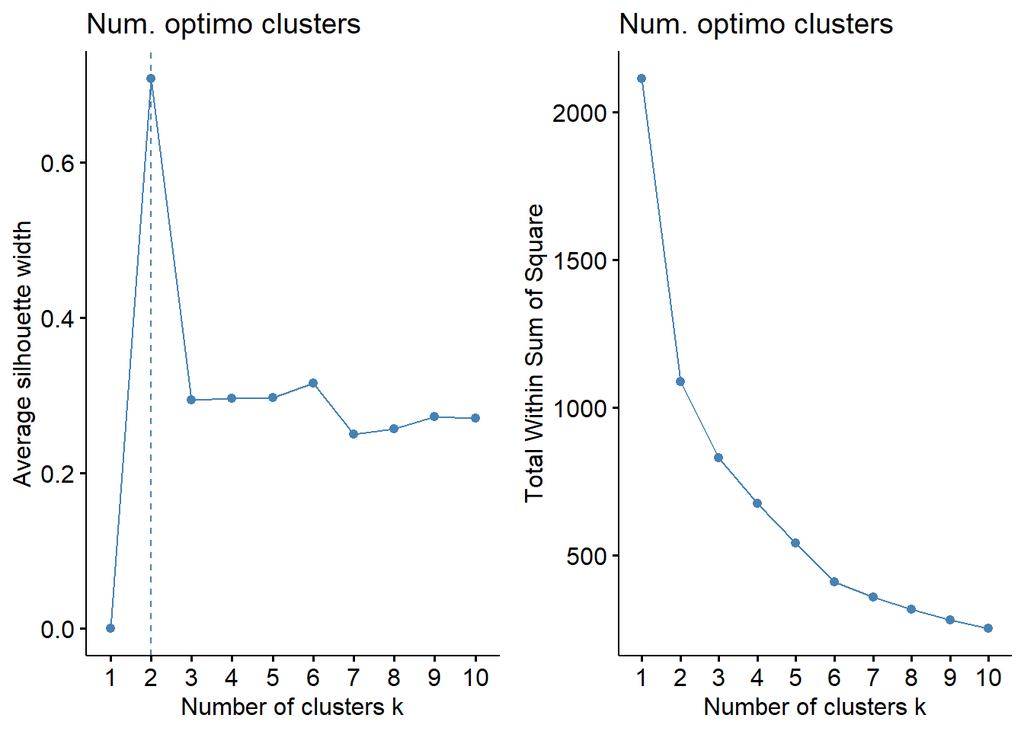

```r
p1 = fviz_nbclust(x = d_aer, FUNcluster = hcut, method = "silhouette",
                  hc_method = "ward.D2", k.max = 10, verbose = FALSE,
                  hc_metric = "euclidean") + labs(title = "Num. optimo clusters")
p2 = fviz_nbclust(x = d_aer, FUNcluster = hcut, method = "wss",
                  hc_method = "ward.D2", k.max = 10, verbose = FALSE,
                  hc_metric = "euclidean") + labs(title = "Num. optimo clusters")
grid.arrange(p1, p2, nrow = 1)
```

```r
clust1 <- hclust(midist, method="ward.D2")
grupos1 <- cutree(clust1, k=6)
table(grupos1)
```

```
## grupos1
##   1   2   3   4   5   6
## 173  96  36   4  27  17
```

```r
clust1_1 <- hclust(midist, method="ward.D2")
grupos1_1 <- cutree(clust1_1, k=4)
table(grupos1_1)
```

```
## grupos1_1
##   1   2   3   4
## 173 123  36  21
```

Veamos mediane un gráfico de scores del PCA aplicado a los datos, cómo se agrupan los aeropuertos en clusters según las dos componentes principales.

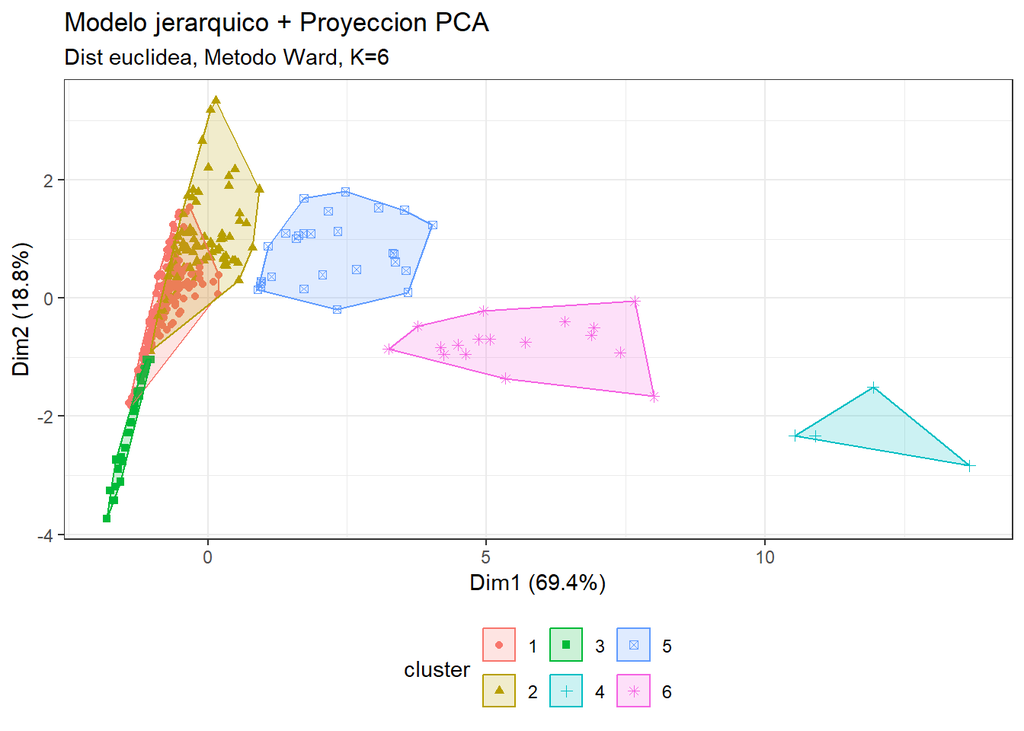

```r
fviz_cluster(object = list(data=d_aer, cluster=grupos1), stand = FALSE,
             ellipse.type = "convex", geom = "point", show.clust.cent = FALSE,
             labelsize = 8)  +
  labs(title = "Modelo jerarquico + Proyeccion PCA",
       subtitle = "Dist euclidea, Metodo Ward, K=6") +
  theme_bw() +
  theme(legend.position = "bottom")
```

Vemos como los clusters 4, 5 y 6 se distinguen con claridad del resto. Sin embargo, los clusters 1, 2 y 3 se solapan bastante en las 2 primeras PC’s.Deberíamos explorar más componentes para ver su comportamiento y decidir si es conveniente o no reagrupar los clusters obtenidos o reducir el número de cluster.

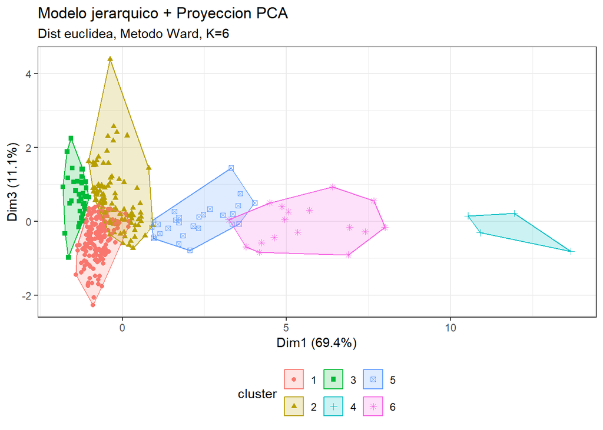

```r
fviz_cluster(object = list(data=d_aer, cluster=grupos1), stand = FALSE,
             ellipse.type = "convex", geom = "point", show.clust.cent = FALSE,
             labelsize = 8, axes = c(1,3))  +
  labs(title = "Modelo jerarquico + Proyeccion PCA",
       subtitle = "Dist euclidea, Metodo Ward, K=6") +
  theme_bw() +
  theme(legend.position = "bottom")
```

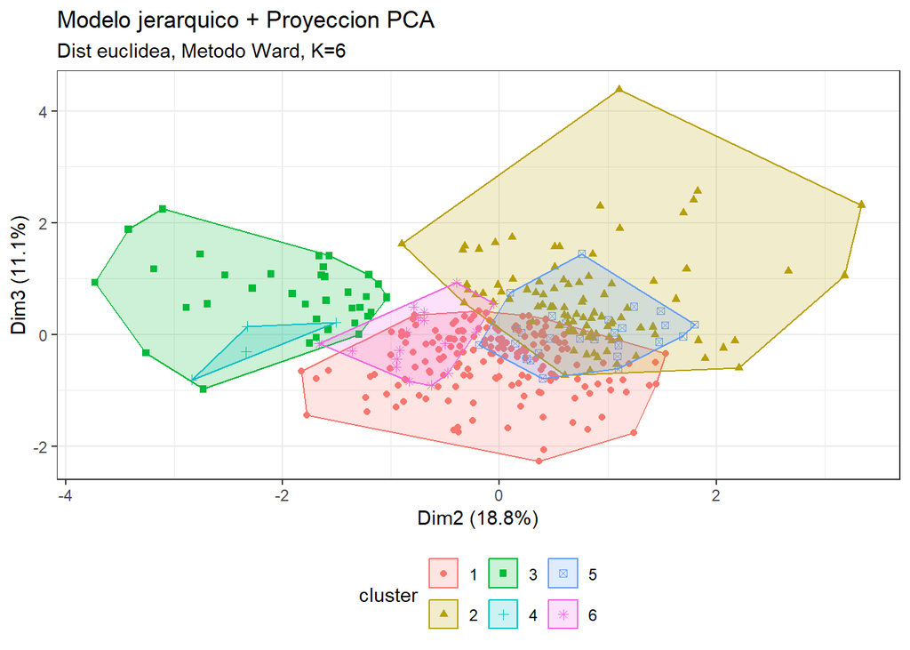

```r
fviz_cluster(object = list(data=d_aer, cluster=grupos1), stand = FALSE,
             ellipse.type = "convex", geom = "point", show.clust.cent = FALSE,
             labelsize = 8, axes = c(2,3))  +
  labs(title = "Modelo jerarquico + Proyeccion PCA",
       subtitle = "Dist euclidea, Metodo Ward, K=6") +
  theme_bw() +
  theme(legend.position = "bottom")
```

### 2.4.2 Método COMPLETE-LINKAGE

Realizamos el mismo estudio con este método:

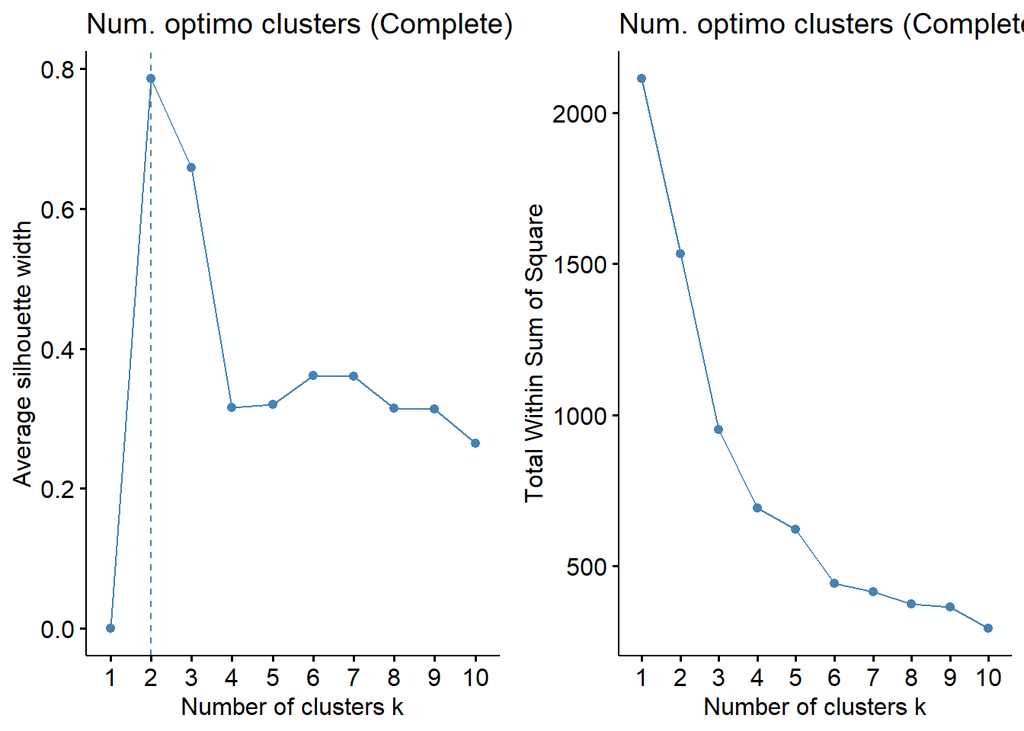

```r
p1 <- fviz_nbclust(x = d_aer, FUNcluster = hcut, method = "silhouette",
                   hc_method = "complete", k.max = 10, verbose = FALSE,
                   hc_metric = "euclidean") + labs(title = "Num. optimo clusters (Complete)")

p2 <- fviz_nbclust(x = d_aer, FUNcluster = hcut, method = "wss",
                   hc_method = "complete", k.max = 10, verbose = FALSE,
                   hc_metric = "euclidean") + labs(title = "Num. optimo clusters (Complete)")

grid.arrange(p1, p2, nrow = 1)
```

```r
clust5 <- hclust(midist, method="complete")
grupos5 <- cutree(clust5, k=6)
table(grupos5)
```

```
## grupos5
##   1   2   3   4   5   6
## 221  80   4  22   9  17
```

Sin embargo, con este clustering no obtenemos una división en clusters más equilibrados por lo que, descartamos este método.

### 2.4.3 Método de la MEDIA

Seguimos con el método de medias:

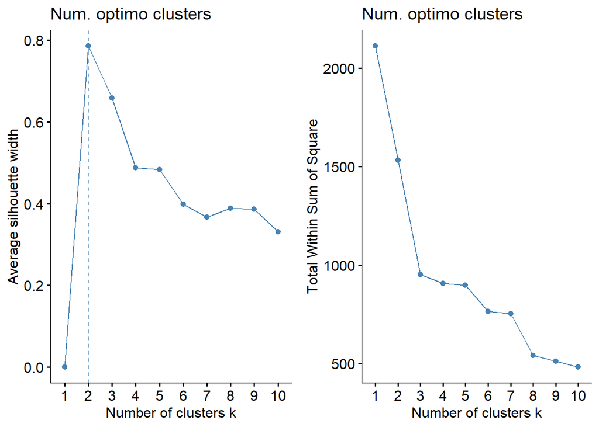

```r
p1 = fviz_nbclust(x = d_aer, FUNcluster = hcut, method = "silhouette",
                  hc_method = "average", k.max = 10, verbose = FALSE,
                  hc_metric = "euclidean") + labs(title = "Num. optimo clusters")
p2 = fviz_nbclust(x = d_aer, FUNcluster = hcut, method = "wss",
                  hc_method = "average", k.max = 10, verbose = FALSE,
                  hc_metric = "euclidean") + labs(title = "Num. optimo clusters")
grid.arrange(p1, p2, nrow = 1)
```

El número óptimo de clusters quitando a 2, sería elegir 3 clusters ya que, es donde se forma el codo y el segundo que más coeficiente de Silhouette proporciona.

```r
clust2 <- hclust(midist, method="average")
grupos2 = cutree(clust2, k = 3)
table(grupos2)
```

```
## grupos2
##   1   2   3
## 332   4  17
```

Sin embargo, la división que realiza no es muy sensata ya que, se crea un cluster que contiene a la gran mayoría de aeropuertos. Descartamos este método.

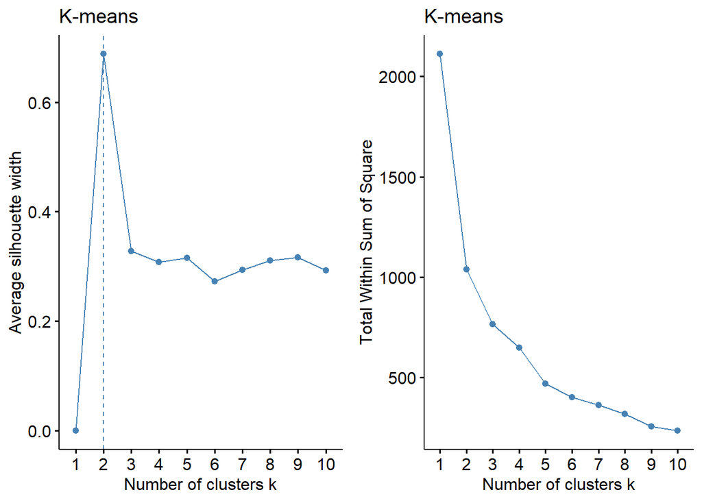

```r
p1 = fviz_nbclust(x = d_aer, FUNcluster = kmeans, method = "silhouette",
             k.max = 10, verbose = FALSE) +
  labs(title = "K-means")
p2 = fviz_nbclust(x = d_aer, FUNcluster = kmeans, method = "wss",
             k.max = 10, verbose = FALSE) +
  labs(title = "K-means")
grid.arrange(p1, p2, nrow = 1)
```

Nos quedamos con 3 y con 5 clusters ya que poseen coef. de Silhouette similares, sin embargo, elegir 5 clusters proporciona menor variabilidad intra-cluster.

```r
clust3 <- kmeans(d_aer, centers = 3, nstart = 20)
table(clust3$cluster)
```

```
##
##   1   2   3
## 185  28 140
```

```r
clust3_3 <- kmeans(d_aer, centers = 5, nstart = 20)
table(clust3_3$cluster)
```

```
##
##   1   2   3   4   5
## 150 125   9  43  26
```

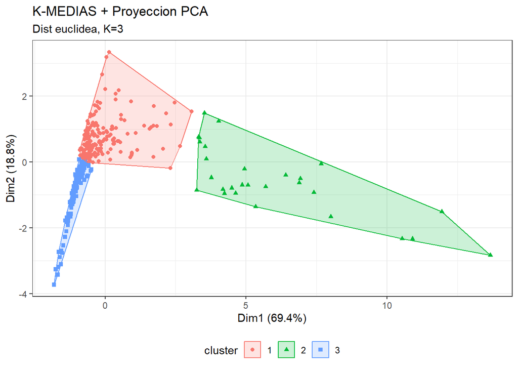

```r
p1 = fviz_cluster(object = list(data=d_aer, cluster=clust3$cluster), stand = FALSE,
             ellipse.type = "convex", geom = "point", show.clust.cent = FALSE,
             labelsize = 8)  +
  labs(title = "K-MEDIAS + Proyeccion PCA",
       subtitle = "Dist euclidea, K=3") +
  theme_bw() +
  theme(legend.position = "bottom")
grid.arrange(p1)
```

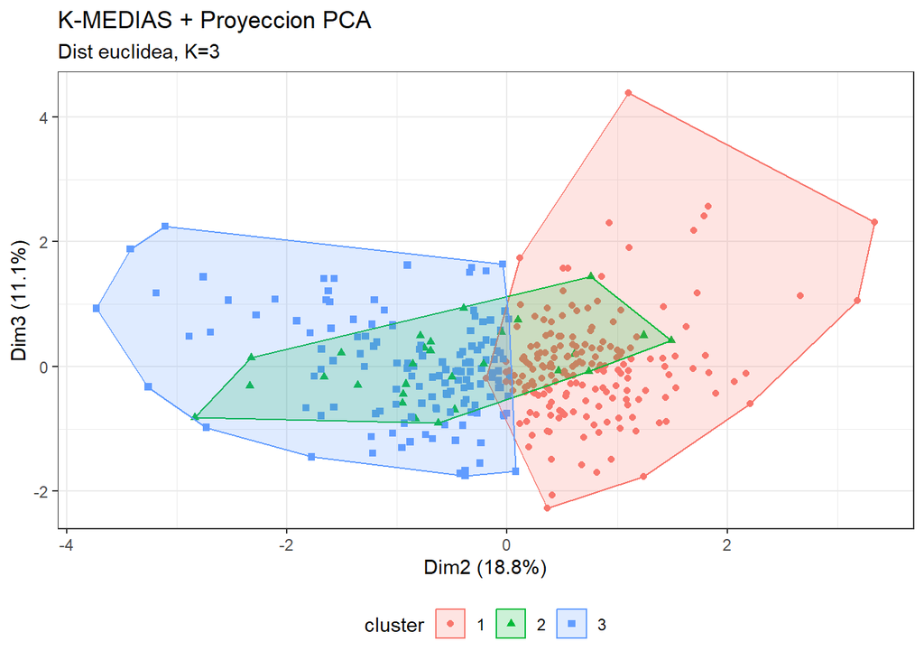

```r
p2 = fviz_cluster(object = list(data=d_aer, cluster=clust3$cluster), stand = FALSE,
             ellipse.type = "convex", geom = "point", show.clust.cent = FALSE,
             labelsize = 8, axes = c(2,3))  +
  labs(title = "K-MEDIAS + Proyeccion PCA",
       subtitle = "Dist euclidea, K=3") +
  theme_bw() +
  theme(legend.position = "bottom")
grid.arrange( p2, nrow = 1)
```

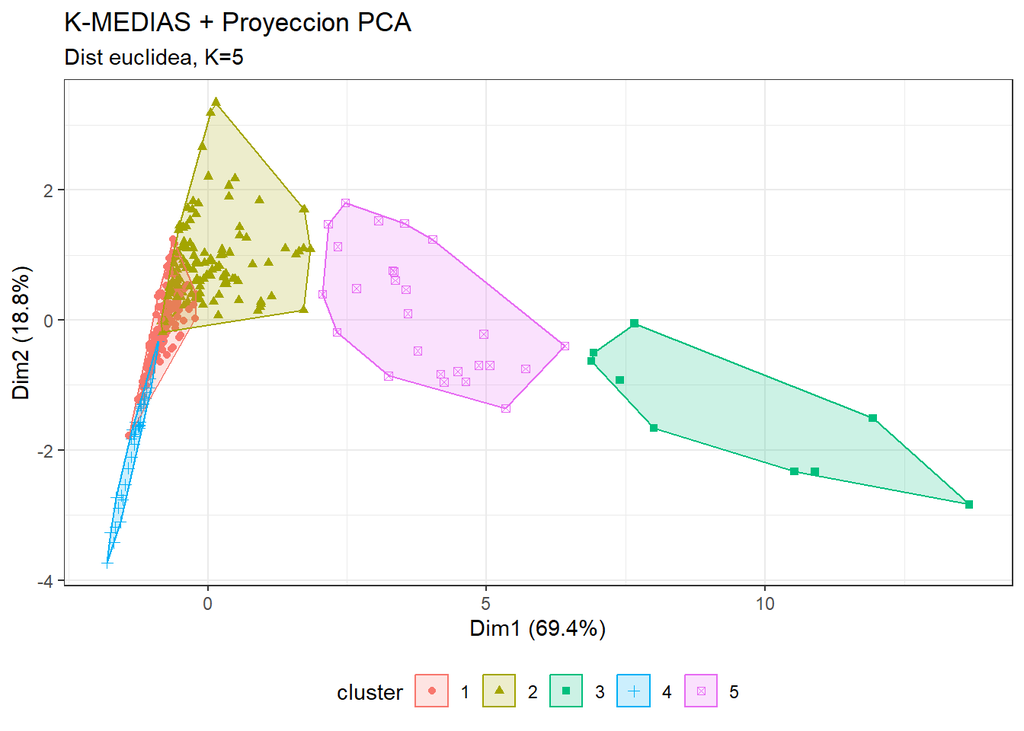

```r
p2 = fviz_cluster(object = list(data=d_aer, cluster=clust3_3$cluster), stand = FALSE,
             ellipse.type = "convex", geom = "point", show.clust.cent = FALSE,
             labelsize = 8, axes = c(1,2))  +
  labs(title = "K-MEDIAS + Proyeccion PCA",
       subtitle = "Dist euclidea, K=5") +
  theme_bw() +
  theme(legend.position = "bottom")
grid.arrange( p2, nrow = 1)
```

A través de las proyecciones PCA, observamos con 3 clusters no se solapan tanto entre sí. Sin embargo, en la proyección con 5 clusters, 3 de ellos aparecen bastante solapados.

### 2.4.4 Método k-medoides

Seguimos con el método de k-medoides:

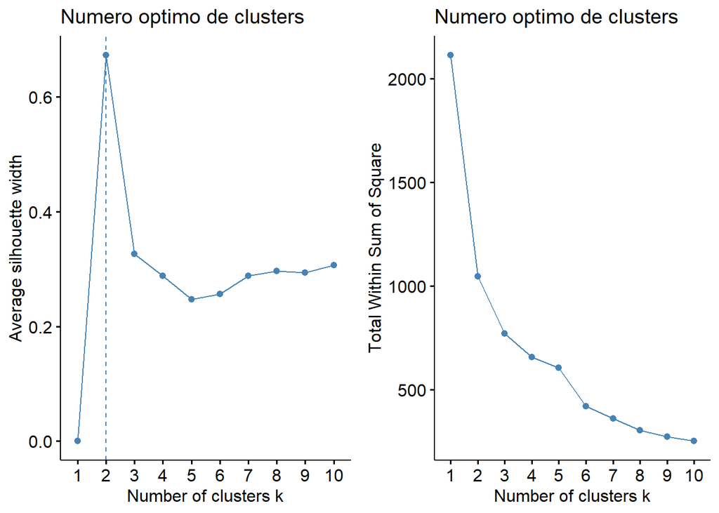

```r
library(cluster)
p1 = fviz_nbclust(x = d_aer, FUNcluster = pam, method = "silhouette",
             k.max = 10, verbose = FALSE) +
  labs(title = "Numero optimo de clusters")
p2 = fviz_nbclust(x = d_aer, FUNcluster = pam, method = "wss",
             k.max = 10, verbose = FALSE) +
  labs(title = "Numero optimo de clusters")
grid.arrange(p1, p2, nrow = 1)
```

Según el criterio de Silhouette, el número óptimo de clusters sería 2, sin embargo,la suma de cuadrados intracluster es un poco elevada, por tanto, nos quedamos con el siguiente óptimo que sería 3 y además parece que es donde se forma el codo.

```r
clust4 <- pam(d_aer, k =3)
table(clust4$clustering)
```

```
##
##   1   2   3
## 150 173  30
```

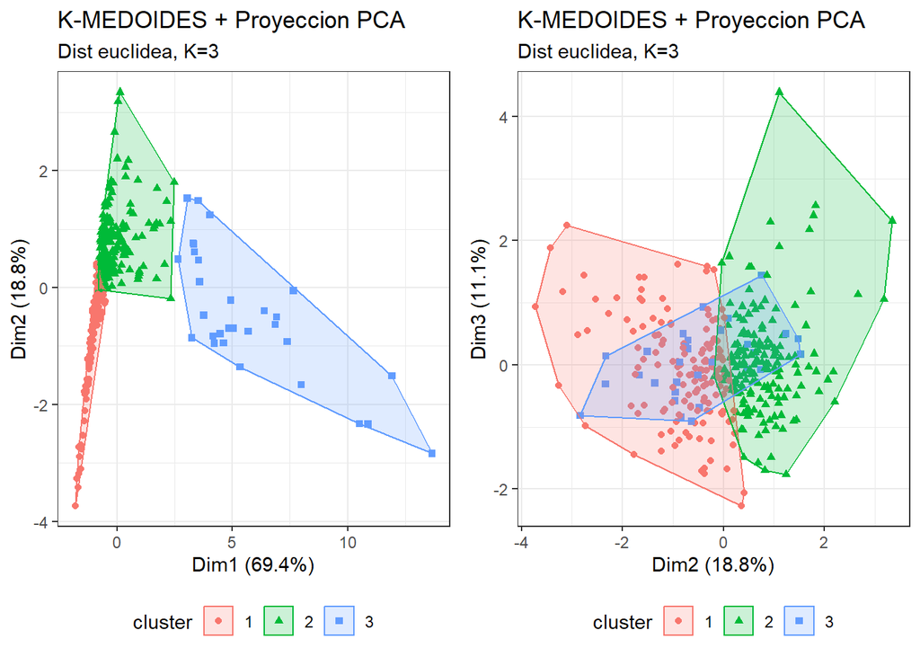

```r
p1 = fviz_cluster(object = list(data=d_aer, cluster=clust4$clustering), stand = FALSE,
             ellipse.type = "convex", geom = "point", show.clust.cent = FALSE,
             labelsize = 8)  +
  labs(title = "K-MEDOIDES + Proyeccion PCA",
       subtitle = "Dist euclidea, K=3") +
  theme_bw() +
  theme(legend.position = "bottom")
p2 = fviz_cluster(object = list(data=d_aer, cluster=clust4$clustering), stand = FALSE,
             ellipse.type = "convex", geom = "point", show.clust.cent = FALSE,
             labelsize = 8, axes =c(2,3))  +
  labs(title = "K-MEDOIDES + Proyeccion PCA",
       subtitle = "Dist euclidea, K=3") +
  theme_bw() +
  theme(legend.position = "bottom")
grid.arrange(p1, p2, nrow = 1)
```

Al igual que observabamos en k-medias en la proyección PCA con 3 clusters, hay 2 clusters que se solapan un poco en las 2 primeras PC’s. Si realizamos la representación de la segunda y la tercera, se separan algo más pero aún se solapan un poco. Veamos con qué método nos quedamos:

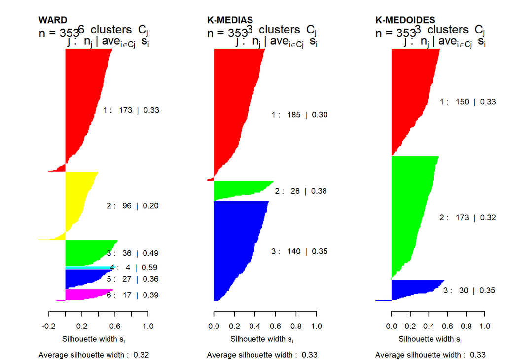

```r
par(mfrow = c(1,3))
plot(silhouette(grupos1, midist), col=rainbow(6), border=NA, main = "WARD")
plot(silhouette(clust3$cluster, midist), col=rainbow(3), border=NA, main = "K-MEDIAS")
plot(silhouette(clust4$clustering, midist), col=rainbow(3), border=NA, main = "K-MEDOIDES")
```

Observando la representación de los coeficientes Silhouette para cada método, parece que el mejor resultado es proporcionad por el algoritmo k-medias, ya que presenta menos aeropuertos mal clasificados (es decir, con coeficiente negativo), por lo que nos decantaremos por este método.